# Predict Bike Sharing Demand with AutoGluon Template

## Project: Predict Bike Sharing Demand with AutoGluon

This notebook is a template with each step that you need to complete for the project.

Please fill in your code where there are explicit `?` markers in the notebook. You are welcome to add more cells and code as you see fit.

Once you have completed all the code implementations, please export your notebook as a HTML file so the reviews can view your code. Make sure you have all outputs correctly outputted.

`File-> Export Notebook As... -> Export Notebook as HTML`

There is a writeup to complete as well after all code implememtation is done. Please answer all questions and attach the necessary tables and charts. You can complete the writeup in either markdown or PDF.

Completing the code template and writeup template will cover all of the rubric points for this project.

The rubric contains "Stand Out Suggestions" for enhancing the project beyond the minimum requirements. The stand out suggestions are optional. If you decide to pursue the "stand out suggestions", you can include the code in this notebook and also discuss the results in the writeup file.

## Step 1: Create an account with Kaggle

### Create Kaggle Account and download API key

Below is example of steps to get the API username and key. Each student will have their own username and key.

1. Open account settings.

2. Scroll down to API and click Create New API Token.

3. Open up `kaggle.json` and use the username and key.


## Step 2: Download the Kaggle dataset using the kaggle python library

### Open up Sagemaker Studio and use starter template

1. Notebook should be using a `ml.t3.medium` instance (2 vCPU + 4 GiB)
2. Notebook should be using kernal: `Python 3 (MXNet 1.8 Python 3.7 CPU Optimized)`

### Install packages

```python
!pip install -U pip
!pip install -U setuptools wheel
!pip install -U "mxnet<2.0.0" bokeh==2.0.1
!pip install autogluon --no-cache-dir
# Without --no-cache-dir, smaller aws instances may have trouble installing
```

[output not shown]

### Setup Kaggle API Key

```python
# create the .kaggle directory and an empty kaggle.json file
# !mkdir -p /root/.kaggle
# !touch /root/.kaggle/kaggle.json
# !chmod 600 /root/.kaggle/kaggle.json
!pip install -q Kaggle
!mkdir ~/.kaggle
!cp kaggle.json ~/.kaggle/
!chmod 600 ~/.kaggle/kaggle.json
!kaggle competitions download -c bike-sharing-demand
!unzip -o bike-sharing-demand.zip
```

```
mkdir: cannot create directory ‘/home/sagemaker-user/.kaggle’: File exists
Downloading bike-sharing-demand.zip to /home/sagemaker-user/nd009t-c1-intro-to-ml-project-starter
Archive:  bike-sharing-demand.zip
  inflating: sampleSubmission.csv
  inflating: test.csv
  inflating: train.csv
```

### Download and explore dataset

### Go to the [bike sharing demand competition](https://www.kaggle.com/c/bike-sharing-demand) and agree to the terms

```python
import numpy as np
import pandas as pd
from autogluon.tabular import TabularPredictor
```

```python
# Create the train dataset in pandas by reading the csv
# Set the parsing of the datetime column so you can use some of the `dt` features in pandas later
train = pd.read_csv("train.csv",parse_dates=["datetime"])
train.head()
```

|  | datetime | season | holiday | workingday | weather | temp | atemp | humidity | windspeed | casual | registered | count |
| --- | --- | --- | --- | --- | --- | --- | --- | --- | --- | --- | --- | --- |
| 0 | 2011-01-01 00:00:00 | 1 | 0 | 0 | 1 | 9.84 | 14.395 | 81 | 0.0 | 3 | 13 | 16 |
| 1 | 2011-01-01 01:00:00 | 1 | 0 | 0 | 1 | 9.02 | 13.635 | 80 | 0.0 | 8 | 32 | 40 |
| 2 | 2011-01-01 02:00:00 | 1 | 0 | 0 | 1 | 9.02 | 13.635 | 80 | 0.0 | 5 | 27 | 32 |
| 3 | 2011-01-01 03:00:00 | 1 | 0 | 0 | 1 | 9.84 | 14.395 | 75 | 0.0 | 3 | 10 | 13 |
| 4 | 2011-01-01 04:00:00 | 1 | 0 | 0 | 1 | 9.84 | 14.395 | 75 | 0.0 | 0 | 1 | 1 |

```python
# Train summary
train.describe()
```

|  | datetime | season | holiday | workingday | weather | temp | atemp | humidity | windspeed | casual | registered | count |
| --- | --- | --- | --- | --- | --- | --- | --- | --- | --- | --- | --- | --- |
| count | 10886 | 10886.000000 | 10886.000000 | 10886.000000 | 10886.000000 | 10886.00000 | 10886.000000 | 10886.000000 | 10886.000000 | 10886.000000 | 10886.000000 | 10886.000000 |
| mean | 2011-12-27 05:56:22.399411968 | 2.506614 | 0.028569 | 0.680875 | 1.418427 | 20.23086 | 23.655084 | 61.886460 | 12.799395 | 36.021955 | 155.552177 | 191.574132 |
| min | 2011-01-01 00:00:00 | 1.000000 | 0.000000 | 0.000000 | 1.000000 | 0.82000 | 0.760000 | 0.000000 | 0.000000 | 0.000000 | 0.000000 | 1.000000 |
| 25% | 2011-07-02 07:15:00 | 2.000000 | 0.000000 | 0.000000 | 1.000000 | 13.94000 | 16.665000 | 47.000000 | 7.001500 | 4.000000 | 36.000000 | 42.000000 |
| 50% | 2012-01-01 20:30:00 | 3.000000 | 0.000000 | 1.000000 | 1.000000 | 20.50000 | 24.240000 | 62.000000 | 12.998000 | 17.000000 | 118.000000 | 145.000000 |
| 75% | 2012-07-01 12:45:00 | 4.000000 | 0.000000 | 1.000000 | 2.000000 | 26.24000 | 31.060000 | 77.000000 | 16.997900 | 49.000000 | 222.000000 | 284.000000 |
| max | 2012-12-19 23:00:00 | 4.000000 | 1.000000 | 1.000000 | 4.000000 | 41.00000 | 45.455000 | 100.000000 | 56.996900 | 367.000000 | 886.000000 | 977.000000 |
| std | NaN | 1.116174 | 0.166599 | 0.466159 | 0.633839 | 7.79159 | 8.474601 | 19.245033 | 8.164537 | 49.960477 | 151.039033 | 181.144454 |

```python
train.info()
```

```
<class 'pandas.core.frame.DataFrame'>
RangeIndex: 10886 entries, 0 to 10885
Data columns (total 12 columns):
 #   Column      Non-Null Count  Dtype
---  ------      --------------  -----
 0   datetime    10886 non-null  datetime64[ns]
 1   season      10886 non-null  int64
 2   holiday     10886 non-null  int64
 3   workingday  10886 non-null  int64
 4   weather     10886 non-null  int64
 5   temp        10886 non-null  float64
 6   atemp       10886 non-null  float64
 7   humidity    10886 non-null  int64
 8   windspeed   10886 non-null  float64
 9   casual      10886 non-null  int64
 10  registered  10886 non-null  int64
 11  count       10886 non-null  int64
dtypes: datetime64[ns](1), float64(3), int64(8)
memory usage: 1020.7 KB
```

```python
# check if null values
train.isnull().sum()
```

```
datetime      0
season        0
holiday       0
workingday    0
weather       0
temp          0
atemp         0
humidity      0
windspeed     0
casual        0
registered    0
count         0
dtype: int64
```

```python
# Create the test pandas dataframe in pandas by reading the csv, remember to parse the datetime!
test = pd.read_csv("test.csv",parse_dates=["datetime"])
test.head()
```

|  | datetime | season | holiday | workingday | weather | temp | atemp | humidity | windspeed |
| --- | --- | --- | --- | --- | --- | --- | --- | --- | --- |
| 0 | 2011-01-20 00:00:00 | 1 | 0 | 1 | 1 | 10.66 | 11.365 | 56 | 26.0027 |
| 1 | 2011-01-20 01:00:00 | 1 | 0 | 1 | 1 | 10.66 | 13.635 | 56 | 0.0000 |
| 2 | 2011-01-20 02:00:00 | 1 | 0 | 1 | 1 | 10.66 | 13.635 | 56 | 0.0000 |
| 3 | 2011-01-20 03:00:00 | 1 | 0 | 1 | 1 | 10.66 | 12.880 | 56 | 11.0014 |
| 4 | 2011-01-20 04:00:00 | 1 | 0 | 1 | 1 | 10.66 | 12.880 | 56 | 11.0014 |

```python
test.isnull().sum()
```

```
datetime      0
season        0
holiday       0
workingday    0
weather       0
temp          0
atemp         0
humidity      0
windspeed     0
dtype: int64
```

```python
print("Train Dataset Shape : ", train.shape)
print("Test Dataset Shape  : ", test.shape)
```

```
Train Dataset Shape :  (10886, 12)
Test Dataset Shape  :  (6493, 9)
```

```python
# Same thing as train and test dataset
submission = pd.read_csv("sampleSubmission.csv",parse_dates=["datetime"])
submission.head()
```

|  | datetime | count |
| --- | --- | --- |
| 0 | 2011-01-20 00:00:00 | 0 |
| 1 | 2011-01-20 01:00:00 | 0 |
| 2 | 2011-01-20 02:00:00 | 0 |
| 3 | 2011-01-20 03:00:00 | 0 |
| 4 | 2011-01-20 04:00:00 | 0 |

```python
print("Columns in Train Dataset:\n", train.columns)
print("\nColumns in Test Dataset:\n", test.columns)
```

```
Columns in Train Dataset:
 Index(['datetime', 'season', 'holiday', 'workingday', 'weather', 'temp',
       'atemp', 'humidity', 'windspeed', 'casual', 'registered', 'count'],
      dtype='object')

Columns in Test Dataset:
 Index(['datetime', 'season', 'holiday', 'workingday', 'weather', 'temp',
       'atemp', 'humidity', 'windspeed'],
      dtype='object')
```

```python
print('variables absent in test:')
list(set(train.columns).difference(set(test.columns)))
```

```
variables absent in test:
```

```
['casual', 'count', 'registered']
```

## Step 3: Train a model using AutoGluon’s Tabular Prediction

Requirements:

- We are predicting `count`, so it is the label we are setting.
- Ignore `casual` and `registered` columns as they are also not present in the test dataset.
- Use the `root_mean_squared_error` as the metric to use for evaluation.
- Set a time limit of 10 minutes (600 seconds).
- Use the preset `best_quality` to focus on creating the best model.

```python
eval_metric = 'root_mean_squared_error'
label = 'count'
ignored_columns = ["casual", "registered"]
train_data = train
time_limit = 600
presets = "best_quality"
```

```python
predictor = TabularPredictor(label=label, problem_type= 'regression', eval_metric=eval_metric, learner_kwargs={'ignored_columns': ignored_columns}).fit(train_data = train_data, time_limit=time_limit, presets=presets)
```

```
No path specified. Models will be saved in: "AutogluonModels/ag-20240510_143540"
Presets specified: ['best_quality']
Stack configuration (auto_stack=True): num_stack_levels=1, num_bag_folds=8, num_bag_sets=20
Beginning AutoGluon training ... Time limit = 600s
AutoGluon will save models to "AutogluonModels/ag-20240510_143540"
AutoGluon Version:  0.8.2
Python Version:     3.10.14
Operating System:   Linux
Platform Machine:   x86_64
Platform Version:   #1 SMP Sat Mar 23 09:49:55 UTC 2024
Disk Space Avail:   4.78 GB / 5.36 GB (89.2%)
	WARNING: Available disk space is low and there is a risk that AutoGluon will run out of disk during fit, causing an exception.
	We recommend a minimum available disk space of 10 GB, and large datasets may require more.
Train Data Rows:    10886
Train Data Columns: 11
Label Column: count
Preprocessing data ...
Using Feature Generators to preprocess the data ...
Dropping user-specified ignored columns: ['casual', 'registered']
Fitting AutoMLPipelineFeatureGenerator...
	Available Memory:                    1965.67 MB
	Train Data (Original)  Memory Usage: 0.78 MB (0.0% of available memory)
	Inferring data type of each feature based on column values. Set feature_metadata_in to manually specify special dtypes of the features.
	Stage 1 Generators:
		Fitting AsTypeFeatureGenerator...
			Note: Converting 2 features to boolean dtype as they only contain 2 unique values.
	Stage 2 Generators:
		Fitting FillNaFeatureGenerator...
	Stage 3 Generators:
		Fitting IdentityFeatureGenerator...
		Fitting DatetimeFeatureGenerator...
	Stage 4 Generators:
		Fitting DropUniqueFeatureGenerator...
	Stage 5 Generators:
		Fitting DropDuplicatesFeatureGenerator...
	Types of features in original data (raw dtype, special dtypes):
		('datetime', []) : 1 | ['datetime']
		('float', [])    : 3 | ['temp', 'atemp', 'windspeed']
		('int', [])      : 5 | ['season', 'holiday', 'workingday', 'weather', 'humidity']
	Types of features in processed data (raw dtype, special dtypes):
```

[output cut: 19 more lines]

```
	'XT': [{'criterion': 'gini', 'ag_args': {'name_suffix': 'Gini', 'problem_types': ['binary', 'multiclass']}}, {'criterion': 'entropy', 'ag_args': {'name_suffix': 'Entr', 'problem_types': ['binary', 'multiclass']}}, {'criterion': 'squared_error', 'ag_args': {'name_suffix': 'MSE', 'problem_types': ['r…
	'KNN': [{'weights': 'uniform', 'ag_args': {'name_suffix': 'Unif'}}, {'weights': 'distance', 'ag_args': {'name_suffix': 'Dist'}}],
}
AutoGluon will fit 2 stack levels (L1 to L2) ...
Fitting 11 L1 models ...
Fitting model: KNeighborsUnif_BAG_L1 ... Training model for up to 399.82s of the 599.87s of remaining time.
	-101.5462	 = Validation score   (-root_mean_squared_error)
	0.05s	 = Training   runtime
	0.04s	 = Validation runtime
Fitting model: KNeighborsDist_BAG_L1 ... Training model for up to 399.68s of the 599.74s of remaining time.
	-84.1251	 = Validation score   (-root_mean_squared_error)
	0.03s	 = Training   runtime
	0.04s	 = Validation runtime
Fitting model: LightGBMXT_BAG_L1 ... Training model for up to 399.57s of the 599.63s of remaining time.
	Fitting 8 child models (S1F1 - S1F8) | Fitting with SequentialLocalFoldFittingStrategy
```

[output not shown]

```
	-131.4609	 = Validation score   (-root_mean_squared_error)
	55.65s	 = Training   runtime
	9.55s	 = Validation runtime
Fitting model: LightGBM_BAG_L1 ... Training model for up to 327.15s of the 527.2s of remaining time.
	Fitting 8 child models (S1F1 - S1F8) | Fitting with SequentialLocalFoldFittingStrategy
```

```
[1000]	valid_set's rmse: 130.818
[1000]	valid_set's rmse: 133.204
[1000]	valid_set's rmse: 130.928
[1000]	valid_set's rmse: 126.846
[1000]	valid_set's rmse: 131.426
[1000]	valid_set's rmse: 133.655
[1000]	valid_set's rmse: 132.155
[1000]	valid_set's rmse: 130.62
```

```
	-131.0542	 = Validation score   (-root_mean_squared_error)
	17.4s	 = Training   runtime
	1.52s	 = Validation runtime
Fitting model: RandomForestMSE_BAG_L1 ... Training model for up to 305.84s of the 505.9s of remaining time.
	-116.5484	 = Validation score   (-root_mean_squared_error)
	16.9s	 = Training   runtime
	0.55s	 = Validation runtime
Fitting model: CatBoost_BAG_L1 ... Training model for up to 287.88s of the 487.93s of remaining time.
	Fitting 8 child models (S1F1 - S1F8) | Fitting with SequentialLocalFoldFittingStrategy
	Ran out of time, early stopping on iteration 4078.
	Ran out of time, early stopping on iteration 4211.
	Ran out of time, early stopping on iteration 4118.
	Ran out of time, early stopping on iteration 4223.
	Ran out of time, early stopping on iteration 4520.
	Ran out of time, early stopping on iteration 5546.
	-130.5915	 = Validation score   (-root_mean_squared_error)
	239.58s	 = Training   runtime
	0.09s	 = Validation runtime
Fitting model: ExtraTreesMSE_BAG_L1 ... Training model for up to 48.06s of the 248.12s of remaining time.
	-124.6007	 = Validation score   (-root_mean_squared_error)
	9.34s	 = Training   runtime
	0.74s	 = Validation runtime
Fitting model: NeuralNetFastAI_BAG_L1 ... Training model for up to 37.24s of the 237.29s of remaining time.
	Fitting 8 child models (S1F1 - S1F8) | Fitting with SequentialLocalFoldFittingStrategy
	Ran out of time, stopping training early. (Stopping on epoch 4)
	Ran out of time, stopping training early. (Stopping on epoch 6)
	Ran out of time, stopping training early. (Stopping on epoch 5)
	Ran out of time, stopping training early. (Stopping on epoch 14)
	-140.7922	 = Validation score   (-root_mean_squared_error)
	34.78s	 = Training   runtime
	0.29s	 = Validation runtime
Fitting model: XGBoost_BAG_L1 ... Training model for up to 2.0s of the 202.06s of remaining time.
	Fitting 8 child models (S1F1 - S1F8) | Fitting with SequentialLocalFoldFittingStrategy
	-134.6812	 = Validation score   (-root_mean_squared_error)
	1.83s	 = Training   runtime
	0.1s	 = Validation runtime
Fitting model: NeuralNetTorch_BAG_L1 ... Training model for up to 0.01s of the 200.07s of remaining time.
	Fitting 8 child models (S1F1 - S1F8) | Fitting with SequentialLocalFoldFittingStrategy
	Time limit exceeded... Skipping NeuralNetTorch_BAG_L1.
Completed 1/20 k-fold bagging repeats ...
Fitting model: WeightedEnsemble_L2 ... Training model for up to 360.0s of the 199.95s of remaining time.
	-84.1251	 = Validation score   (-root_mean_squared_error)
	0.47s	 = Training   runtime
	0.0s	 = Validation runtime
Fitting 9 L2 models ...
Fitting model: LightGBMXT_BAG_L2 ... Training model for up to 199.47s of the 199.46s of remaining time.
	Fitting 8 child models (S1F1 - S1F8) | Fitting with SequentialLocalFoldFittingStrategy
```

```
[1000]	valid_set's rmse: 60.9783
[2000]	valid_set's rmse: 59.9234
[3000]	valid_set's rmse: 59.8431
[1000]	valid_set's rmse: 60.3511
[2000]	valid_set's rmse: 58.8908
[3000]	valid_set's rmse: 58.9045
[1000]	valid_set's rmse: 62.8754
[2000]	valid_set's rmse: 61.7809
[1000]	valid_set's rmse: 64.5814
[2000]	valid_set's rmse: 62.586
[1000]	valid_set's rmse: 58.2231
[2000]	valid_set's rmse: 57.547
[1000]	valid_set's rmse: 63.7676
[2000]	valid_set's rmse: 62.6705
[1000]	valid_set's rmse: 63.4775
[2000]	valid_set's rmse: 62.3755
[3000]	valid_set's rmse: 62.3391
[1000]	valid_set's rmse: 58.0583
[2000]	valid_set's rmse: 57.3566
```

```
	-60.3325	 = Validation score   (-root_mean_squared_error)
	53.85s	 = Training   runtime
	3.61s	 = Validation runtime
Fitting model: LightGBM_BAG_L2 ... Training model for up to 137.76s of the 137.75s of remaining time.
	Fitting 8 child models (S1F1 - S1F8) | Fitting with SequentialLocalFoldFittingStrategy
	-54.9692	 = Validation score   (-root_mean_squared_error)
	15.27s	 = Training   runtime
	0.28s	 = Validation runtime
Fitting model: RandomForestMSE_BAG_L2 ... Training model for up to 121.77s of the 121.76s of remaining time.
	-53.1476	 = Validation score   (-root_mean_squared_error)
	44.45s	 = Training   runtime
	0.86s	 = Validation runtime
Fitting model: CatBoost_BAG_L2 ... Training model for up to 75.82s of the 75.8s of remaining time.
	Fitting 8 child models (S1F1 - S1F8) | Fitting with SequentialLocalFoldFittingStrategy
	Ran out of time, early stopping on iteration 1227.
	Ran out of time, early stopping on iteration 1066.
	Ran out of time, early stopping on iteration 1083.
	Ran out of time, early stopping on iteration 1091.
	Ran out of time, early stopping on iteration 986.
	Ran out of time, early stopping on iteration 1467.
	-55.6149	 = Validation score   (-root_mean_squared_error)
	68.12s	 = Training   runtime
	0.06s	 = Validation runtime
Fitting model: ExtraTreesMSE_BAG_L2 ... Training model for up to 7.54s of the 7.51s of remaining time.
	-53.7471	 = Validation score   (-root_mean_squared_error)
	15.47s	 = Training   runtime
	0.93s	 = Validation runtime
Completed 1/20 k-fold bagging repeats ...
Fitting model: WeightedEnsemble_L3 ... Training model for up to 360.0s of the -9.4s of remaining time.
	-52.6369	 = Validation score   (-root_mean_squared_error)
	0.28s	 = Training   runtime
	0.0s	 = Validation runtime
AutoGluon training complete, total runtime = 609.7s ... Best model: "WeightedEnsemble_L3"
TabularPredictor saved. To load, use: predictor = TabularPredictor.load("AutogluonModels/ag-20240510_143540")
```

### Review AutoGluon's training run with ranking of models that did the best.

```python
predictor.fit_summary()
```

```
*** Summary of fit() ***
Estimated performance of each model:
                     model   score_val  pred_time_val    fit_time  pred_time_val_marginal  fit_time_marginal  stack_level  can_infer  fit_order
0      WeightedEnsemble_L3  -52.636855      15.009071  451.038094                0.000796           0.275406            3       True         16
1   RandomForestMSE_BAG_L2  -53.147635      13.797040  420.020282                0.862025          44.449311            2       True         13
2     ExtraTreesMSE_BAG_L2  -53.747108      13.861943  391.039061                0.926928          15.468089            2       True         15
3          LightGBM_BAG_L2  -54.969193      13.219321  390.845287                0.284306          15.274316            2       True         12
4          CatBoost_BAG_L2  -55.614872      12.998046  443.687299                0.063030          68.116328            2       True         14
5        LightGBMXT_BAG_L2  -60.332450      16.543747  429.419681                3.608732          53.848709            2       True         11
6    KNeighborsDist_BAG_L1  -84.125061       0.044907    0.031754                0.044907           0.031754            1       True          2
7      WeightedEnsemble_L2  -84.125061       0.045757    0.503299                0.000851           0.471546            2       True         10
8    KNeighborsUnif_BAG_L1 -101.546199       0.044565    0.052489                0.044565           0.052489            1       True          1
9   RandomForestMSE_BAG_L1 -116.548359       0.554410   16.901506                0.554410          16.901506            1       True          5
10    ExtraTreesMSE_BAG_L1 -124.600676       0.736952    9.342351                0.736952           9.342351            1       True          7
11         CatBoost_BAG_L1 -130.591523       0.089650  239.581528                0.089650         239.581528            1       True          6
12         LightGBM_BAG_L1 -131.054162       1.521632   17.398072                1.521632          17.398072            1       True          4
13       LightGBMXT_BAG_L1 -131.460909       9.554999   55.654567                9.554999          55.654567            1       True          3
14          XGBoost_BAG_L1 -134.681245       0.100812    1.826018                0.100812           1.826018            1       True          9
15  NeuralNetFastAI_BAG_L1 -140.792181       0.287090   34.782687                0.287090          34.782687            1       True          8
Number of models trained: 16
Types of models trained:
{'StackerEnsembleModel_RF', 'StackerEnsembleModel_XT', 'StackerEnsembleModel_LGB', 'StackerEnsembleModel_CatBoost', 'StackerEnsembleModel_XGBoost', 'WeightedEnsembleModel', 'StackerEnsembleModel_NNFastAiTabular', 'StackerEnsembleModel_KNN'}
Bagging used: True  (with 8 folds)
Multi-layer stack-ensembling used: True  (with 3 levels)
Feature Metadata (Processed):
(raw dtype, special dtypes):
('float', [])                : 3 | ['temp', 'atemp', 'windspeed']
('int', [])                  : 3 | ['season', 'weather', 'humidity']
('int', ['bool'])            : 2 | ['holiday', 'workingday']
('int', ['datetime_as_int']) : 5 | ['datetime', 'datetime.year', 'datetime.month', 'datetime.day', 'datetime.dayofweek']
*** End of fit() summary ***
```

[output not shown]

[output cut: 151 more lines]

```
 1          13
 2          15
 3          12
 4          14
 5          11
 6           2
 7          10
 8           1
 9           5
 10          7
 11          6
 12          4
 13          3
 14          9
 15          8  }
```

```python
leaderboard_df = pd.DataFrame(predictor.leaderboard(silent=True))
leaderboard_df
```

|  | model | score_val | pred_time_val | fit_time | pred_time_val_marginal | fit_time_marginal | stack_level | can_infer | fit_order |
| --- | --- | --- | --- | --- | --- | --- | --- | --- | --- |
| 0 | WeightedEnsemble_L3 | -52.636855 | 15.009071 | 451.038094 | 0.000796 | 0.275406 | 3 | True | 16 |
| 1 | RandomForestMSE_BAG_L2 | -53.147635 | 13.797040 | 420.020282 | 0.862025 | 44.449311 | 2 | True | 13 |
| 2 | ExtraTreesMSE_BAG_L2 | -53.747108 | 13.861943 | 391.039061 | 0.926928 | 15.468089 | 2 | True | 15 |
| 3 | LightGBM_BAG_L2 | -54.969193 | 13.219321 | 390.845287 | 0.284306 | 15.274316 | 2 | True | 12 |
| 4 | CatBoost_BAG_L2 | -55.614872 | 12.998046 | 443.687299 | 0.063030 | 68.116328 | 2 | True | 14 |
| 5 | LightGBMXT_BAG_L2 | -60.332450 | 16.543747 | 429.419681 | 3.608732 | 53.848709 | 2 | True | 11 |
| 6 | KNeighborsDist_BAG_L1 | -84.125061 | 0.044907 | 0.031754 | 0.044907 | 0.031754 | 1 | True | 2 |
| 7 | WeightedEnsemble_L2 | -84.125061 | 0.045757 | 0.503299 | 0.000851 | 0.471546 | 2 | True | 10 |
| 8 | KNeighborsUnif_BAG_L1 | -101.546199 | 0.044565 | 0.052489 | 0.044565 | 0.052489 | 1 | True | 1 |
| 9 | RandomForestMSE_BAG_L1 | -116.548359 | 0.554410 | 16.901506 | 0.554410 | 16.901506 | 1 | True | 5 |
| 10 | ExtraTreesMSE_BAG_L1 | -124.600676 | 0.736952 | 9.342351 | 0.736952 | 9.342351 | 1 | True | 7 |
| 11 | CatBoost_BAG_L1 | -130.591523 | 0.089650 | 239.581528 | 0.089650 | 239.581528 | 1 | True | 6 |
| 12 | LightGBM_BAG_L1 | -131.054162 | 1.521632 | 17.398072 | 1.521632 | 17.398072 | 1 | True | 4 |
| 13 | LightGBMXT_BAG_L1 | -131.460909 | 9.554999 | 55.654567 | 9.554999 | 55.654567 | 1 | True | 3 |
| 14 | XGBoost_BAG_L1 | -134.681245 | 0.100812 | 1.826018 | 0.100812 | 1.826018 | 1 | True | 9 |
| 15 | NeuralNetFastAI_BAG_L1 | -140.792181 | 0.287090 | 34.782687 | 0.287090 | 34.782687 | 1 | True | 8 |

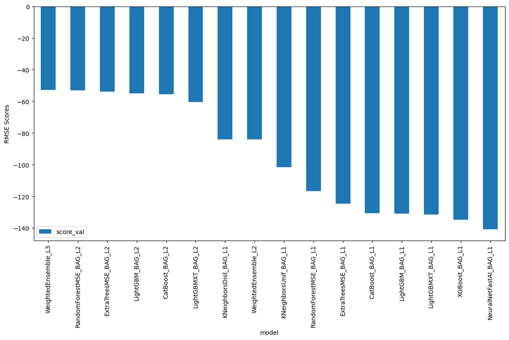

```python
import matplotlib.pyplot as plt
leaderboard_df.plot(kind="bar", x="model", y="score_val", figsize=(14, 7))
plt.ylabel("RMSE Scores")
plt.show()
```

### Create predictions from test dataset

```python
predictions = predictor.predict(test)
predictions.head()
```

```
0    23.434788
1    41.242737
2    45.105930
3    47.959263
4    51.594372
Name: count, dtype: float32
```

#### NOTE: Kaggle will reject the submission if we don't set everything to be > 0.

```python
# Describe the `predictions` series to see if there are any negative values
predictions.describe()
```

```
count    6493.000000
mean      100.959167
std        90.081650
min         2.716236
25%        22.303865
50%        62.560966
75%       170.706299
max       364.147583
Name: count, dtype: float64
```

```python
# How many negative values do we have?
negative_pred_count = predictions.apply(lambda x: 1 if x<0 else 0)

pred_pos_count = (negative_pred_count==0).sum()
pred_neg_count = (negative_pred_count==1).sum()

print("Total predictions                :", len(predictions.index))
print("Total positive prediction values :", pred_pos_count)
print("Total negative prediction values :", pred_neg_count)
```

```
Total predictions                : 6493
Total positive prediction values : 6493
Total negative prediction values : 0
```

```python
# Set them to zero
predictions[predictions<0] = 0    # (In case, if negative values exist in the predictions, set them to 0)

# Rechecking, if no predictions are less than 0
negative_pred_count = predictions.apply(lambda x: 1 if x<0 else 0)
pred_neg_count = (negative_pred_count==1).sum()
print(f"No. of negative predictions: {pred_neg_count}")
print("All negative values in the predictions (if any) are set to zero successfully.")
```

```
No. of negative predictions: 0
All negative values in the predictions (if any) are set to zero successfully.
```

### Set predictions to submission dataframe, save, and submit

```python
submission["count"] = predictions
submission.to_csv("submission.csv", index=False)
```

```python
!kaggle competitions submit -c bike-sharing-demand -f submission.csv -m "first raw submission"
```

```
Successfully submitted to Bike Sharing Demand
```

#### View submission via the command line or in the web browser under the competition's page - `My Submissions`

```python
!kaggle competitions submissions -c bike-sharing-demand | tail -n +1 | head -n 6
```

```
fileName        date                 description           status    publicScore  privateScore
--------------  -------------------  --------------------  --------  -----------  ------------
submission.csv  2024-05-10 14:54:54  first raw submission  complete  1.79874      1.79874
```

#### Initial score of 1.79874

## Step 4: Exploratory Data Analysis and Creating an additional feature

- Any additional feature will do, but a great suggestion would be to separate out the datetime into hour, day, or month parts.

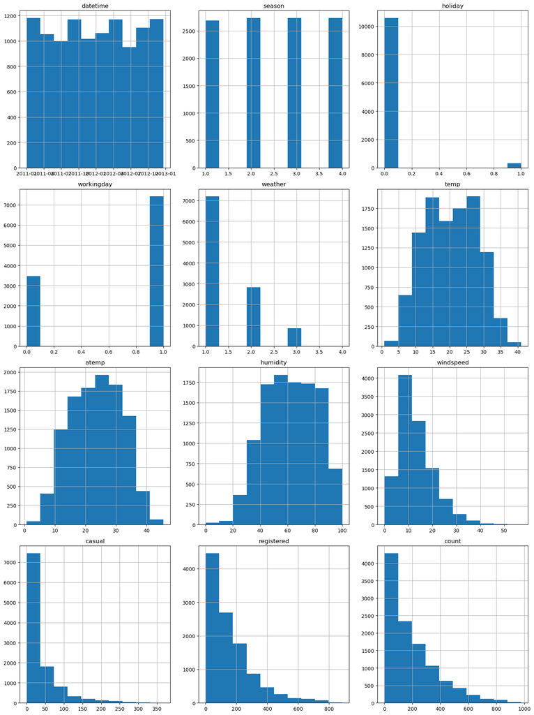

```python
# Create a histogram of all features to show the distribution of each one relative to the data. This is part of the exploritory data analysis
train.hist(figsize=(15,20))  # Note: 'casual' and 'registered' are ignored during training as they are absent in test data

plt.tight_layout()
plt.show()
```

```python
pip install seaborn
```

```
Downloading seaborn-0.13.2-py3-none-any.whl (294 kB)
   ━━━━━━━━━━━━━━━━━━━━━━━━━━━━━━━━━━━━━━━━ 294.9/294.9 kB 17.3 MB/s eta 0:00:00
```

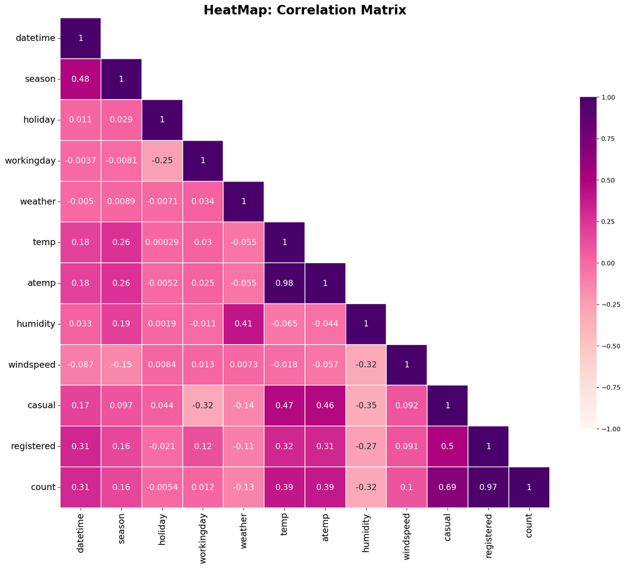

```python
import numpy as np
import matplotlib.pyplot as plt
import seaborn as sns
plt.figure(figsize = (15,15), dpi=120)
corr_data = train.copy()

corr_matrix = corr_data.corr()
f, ax_corr1 = plt.subplots(figsize=(15, 15), dpi=120)
# Create a mask to eliminate redundant repetitive correlations
corr_mask = np.array(corr_matrix)
corr_mask[np.tril_indices_from(corr_mask)] = False

# Plot heatmap using correlation matrix and mask
ax_corr1 = sns.heatmap(corr_matrix, cmap= 'RdPu', cbar_kws={"shrink": .5}, vmin= -1, vmax=1, center=0,
            square=True, mask=corr_mask, annot=True, linewidths=0.01, annot_kws={"size":13})
plt.xticks(fontsize=14, rotation=90)
plt.yticks(fontsize=14, rotation=0)
plt.title("HeatMap: Correlation Matrix", fontsize=20, fontweight='bold')
plt.tight_layout()
plt.autoscale()
plt.show()
```

```python
# create a new feature
train['datetime'].head()
```

```
0   2011-01-01 00:00:00
1   2011-01-01 01:00:00
2   2011-01-01 02:00:00
3   2011-01-01 03:00:00
4   2011-01-01 04:00:00
Name: datetime, dtype: datetime64[ns]
```

```python
train["year"] = train["datetime"].dt.year
train["month"] = train["datetime"].dt.month
train["day"] = train["datetime"].dt.dayofweek  # Note: day -> dayofweek (0->Monday, 6->Sunday)
train["hour"] = train["datetime"].dt.hour
train.drop(["datetime"], axis=1, inplace=True)     # Drop 'datetime' feature
train.head()
```

|  | season | holiday | workingday | weather | temp | atemp | humidity | windspeed | casual | registered | count | year | month | day | hour |
| --- | --- | --- | --- | --- | --- | --- | --- | --- | --- | --- | --- | --- | --- | --- | --- |
| 0 | 1 | 0 | 0 | 1 | 9.84 | 14.395 | 81 | 0.0 | 3 | 13 | 16 | 2011 | 1 | 5 | 0 |
| 1 | 1 | 0 | 0 | 1 | 9.02 | 13.635 | 80 | 0.0 | 8 | 32 | 40 | 2011 | 1 | 5 | 1 |
| 2 | 1 | 0 | 0 | 1 | 9.02 | 13.635 | 80 | 0.0 | 5 | 27 | 32 | 2011 | 1 | 5 | 2 |
| 3 | 1 | 0 | 0 | 1 | 9.84 | 14.395 | 75 | 0.0 | 3 | 10 | 13 | 2011 | 1 | 5 | 3 |
| 4 | 1 | 0 | 0 | 1 | 9.84 | 14.395 | 75 | 0.0 | 0 | 1 | 1 | 2011 | 1 | 5 | 4 |

```python
test["year"] = test["datetime"].dt.year
test["month"] = test["datetime"].dt.month
test["day"] = test["datetime"].dt.dayofweek  # Note: day -> dayofweek (0->Monday, 6->Sunday)
test["hour"] = test["datetime"].dt.hour
test.drop(["datetime"], axis=1, inplace=True)   # Drop 'datetime' feature
test.head()
```

|  | season | holiday | workingday | weather | temp | atemp | humidity | windspeed | year | month | day | hour |
| --- | --- | --- | --- | --- | --- | --- | --- | --- | --- | --- | --- | --- |
| 0 | 1 | 0 | 1 | 1 | 10.66 | 11.365 | 56 | 26.0027 | 2011 | 1 | 3 | 0 |
| 1 | 1 | 0 | 1 | 1 | 10.66 | 13.635 | 56 | 0.0000 | 2011 | 1 | 3 | 1 |
| 2 | 1 | 0 | 1 | 1 | 10.66 | 13.635 | 56 | 0.0000 | 2011 | 1 | 3 | 2 |
| 3 | 1 | 0 | 1 | 1 | 10.66 | 12.880 | 56 | 11.0014 | 2011 | 1 | 3 | 3 |
| 4 | 1 | 0 | 1 | 1 | 10.66 | 12.880 | 56 | 11.0014 | 2011 | 1 | 3 | 4 |

```python
train.info()
```

```
<class 'pandas.core.frame.DataFrame'>
RangeIndex: 10886 entries, 0 to 10885
Data columns (total 15 columns):
 #   Column      Non-Null Count  Dtype
---  ------      --------------  -----
 0   season      10886 non-null  int64
 1   holiday     10886 non-null  int64
 2   workingday  10886 non-null  int64
 3   weather     10886 non-null  int64
 4   temp        10886 non-null  float64
 5   atemp       10886 non-null  float64
 6   humidity    10886 non-null  int64
 7   windspeed   10886 non-null  float64
 8   casual      10886 non-null  int64
 9   registered  10886 non-null  int64
 10  count       10886 non-null  int64
 11  year        10886 non-null  int32
 12  month       10886 non-null  int32
 13  day         10886 non-null  int32
 14  hour        10886 non-null  int32
dtypes: float64(3), int32(4), int64(8)
memory usage: 1.1 MB
```

## Make category types for these so models know they are not just numbers

- AutoGluon originally sees these as ints, but in reality they are int representations of a category.
- Setting the dtype to category will classify these as categories in AutoGluon.

```python
train["season"] = train["season"].astype("category")
train["weather"] = train["weather"].astype("category")
test["season"] = test["season"].astype("category")
test["weather"] = test["weather"].astype("category")
```

```python
# View are new feature
train.head()
```

|  | season | holiday | workingday | weather | temp | atemp | humidity | windspeed | casual | registered | count | year | month | day | hour |
| --- | --- | --- | --- | --- | --- | --- | --- | --- | --- | --- | --- | --- | --- | --- | --- |
| 0 | 1 | 0 | 0 | 1 | 9.84 | 14.395 | 81 | 0.0 | 3 | 13 | 16 | 2011 | 1 | 5 | 0 |
| 1 | 1 | 0 | 0 | 1 | 9.02 | 13.635 | 80 | 0.0 | 8 | 32 | 40 | 2011 | 1 | 5 | 1 |
| 2 | 1 | 0 | 0 | 1 | 9.02 | 13.635 | 80 | 0.0 | 5 | 27 | 32 | 2011 | 1 | 5 | 2 |
| 3 | 1 | 0 | 0 | 1 | 9.84 | 14.395 | 75 | 0.0 | 3 | 10 | 13 | 2011 | 1 | 5 | 3 |
| 4 | 1 | 0 | 0 | 1 | 9.84 | 14.395 | 75 | 0.0 | 0 | 1 | 1 | 2011 | 1 | 5 | 4 |

```python
# View histogram of all features again now with the hour feature
train.info()
```

```
<class 'pandas.core.frame.DataFrame'>
RangeIndex: 10886 entries, 0 to 10885
Data columns (total 15 columns):
 #   Column      Non-Null Count  Dtype
---  ------      --------------  -----
 0   season      10886 non-null  category
 1   holiday     10886 non-null  int64
 2   workingday  10886 non-null  int64
 3   weather     10886 non-null  category
 4   temp        10886 non-null  float64
 5   atemp       10886 non-null  float64
 6   humidity    10886 non-null  int64
 7   windspeed   10886 non-null  float64
 8   casual      10886 non-null  int64
 9   registered  10886 non-null  int64
 10  count       10886 non-null  int64
 11  year        10886 non-null  int32
 12  month       10886 non-null  int32
 13  day         10886 non-null  int32
 14  hour        10886 non-null  int32
dtypes: category(2), float64(3), int32(4), int64(6)
memory usage: 957.3 KB
```

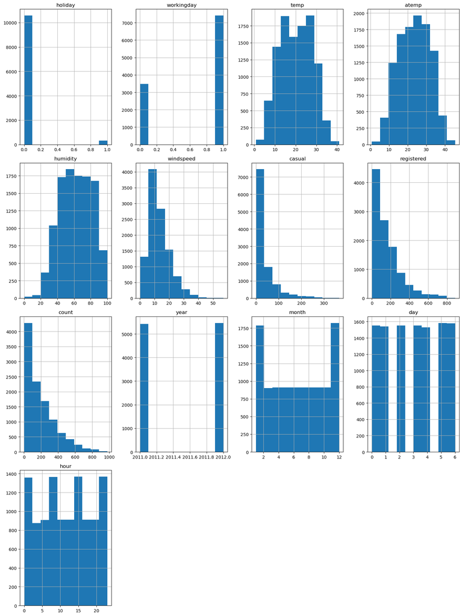

```python
train.hist(figsize=(15,20))  # Note: 'casual' and 'registered' are ignored during training as they are absent in test data
plt.tight_layout()
plt.show()
```

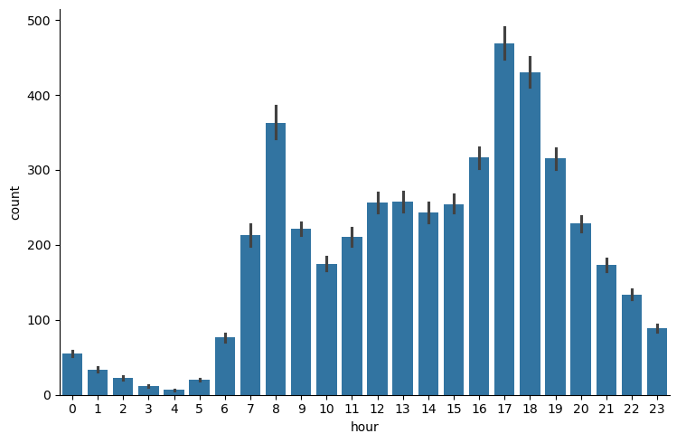

```python
# Variation in`count` w.r.t `hour`

# Using catplot: 'kind':bar makes sure to take value of 'count' for every record into account
sns.catplot(x="hour",y="count",data=train,kind='bar',height=5,aspect=1.5)
plt.tight_layout()
plt.show()
```

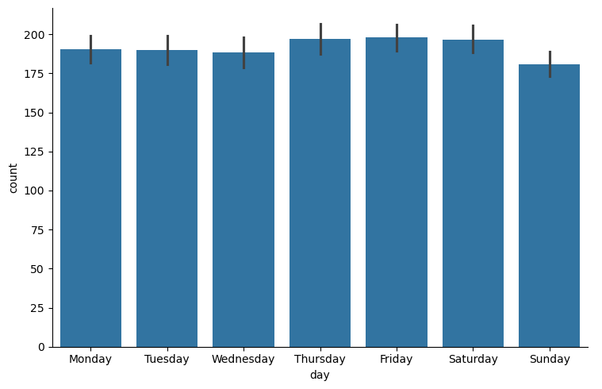

```python
sns.catplot(x="day",y="count",data=train,kind='bar',height=5,aspect=1.5)
plt.tight_layout()
plt.xticks(ticks=range(0,7), labels=["Monday", "Tuesday", "Wednesday",
                                     "Thursday", "Friday", "Saturday", "Sunday"])
plt.show()
```

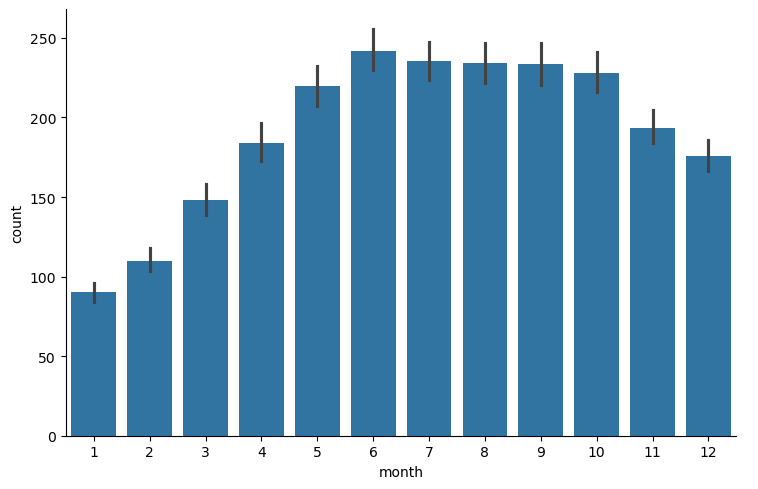

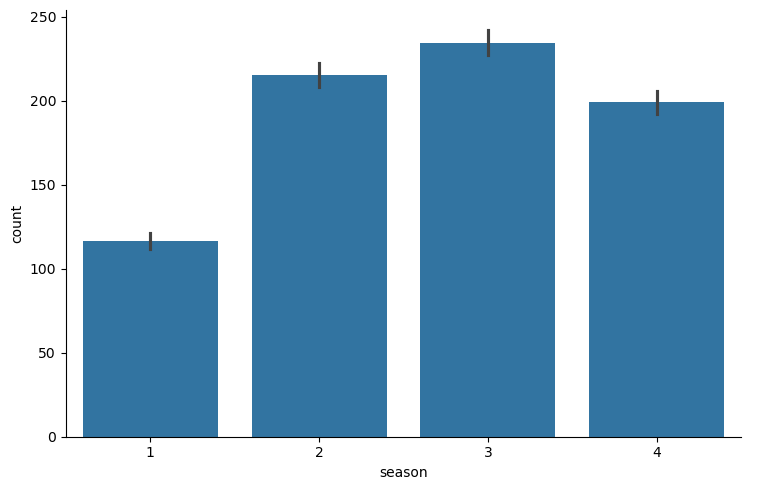

```python
# Using catplot: 'kind':bar makes sure to take value of 'count' for every record into account
sns.catplot(x="month",y="count",data=train,kind='bar',height=5,aspect=1.5)
sns.catplot(x="season",y="count",data=train,kind='bar',height=5,aspect=1.5)
plt.tight_layout()
plt.show()
```

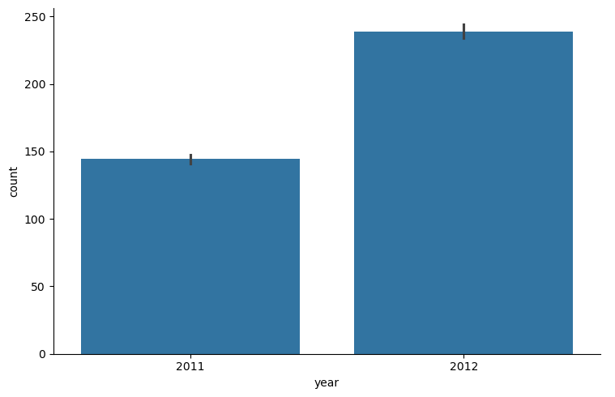

```python
# Using catplot: 'kind':bar makes sure to take value of 'count' for every record into account
sns.catplot(x="year",y="count",data=train,kind='bar',height=5,aspect=1.5)
plt.tight_layout()
plt.show()
```

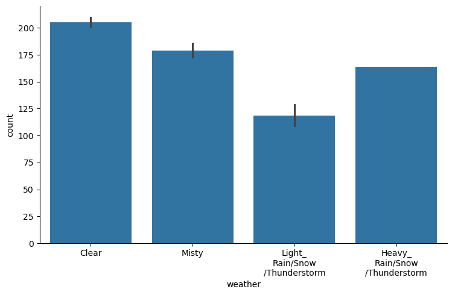

```python
sns.catplot(x="weather",y="count",data=train,kind='bar',height=5,aspect=1.5)
plt.xticks(ticks=range(0,4), labels=["Clear","Misty",
                                     "Light_\nRain/Snow\n/Thunderstorm",
                                     "Heavy_\nRain/Snow\n/Thunderstorm"])
plt.tight_layout()
plt.show()
```

```python
# New feature 'day_type' contains categories 'weekend', 'weekday', or 'holiday' (In Train and Test set)

# Adding features - 'day_type' in train data
train["day_type"]=""
train.loc[(train.holiday==1),"day_type"] = "holiday"
train.loc[((train.holiday==0) & (train.workingday==1)), "day_type"] = "weekday"
train.loc[((train.holiday==0) & (train.workingday==0)), "day_type"] = "weekend"

# Adding features - 'day_type' in test data
test["day_type"]=""
test.loc[(test.holiday==1),"day_type"] = "holiday"
test.loc[((test.holiday==0) & (test.workingday==1)), "day_type"] = "weekday"
test.loc[((test.holiday==0) & (test.workingday==0)), "day_type"] = "weekend"

# Change the datatype to category
train["day_type"] = train["day_type"].astype("category")
test["day_type"] = test["day_type"].astype("category")

train.head()
```

|  | season | holiday | workingday | weather | temp | atemp | humidity | windspeed | casual | registered | count | year | month | day | hour | day_type |
| --- | --- | --- | --- | --- | --- | --- | --- | --- | --- | --- | --- | --- | --- | --- | --- | --- |
| 0 | 1 | 0 | 0 | 1 | 9.84 | 14.395 | 81 | 0.0 | 3 | 13 | 16 | 2011 | 1 | 5 | 0 | weekend |
| 1 | 1 | 0 | 0 | 1 | 9.02 | 13.635 | 80 | 0.0 | 8 | 32 | 40 | 2011 | 1 | 5 | 1 | weekend |
| 2 | 1 | 0 | 0 | 1 | 9.02 | 13.635 | 80 | 0.0 | 5 | 27 | 32 | 2011 | 1 | 5 | 2 | weekend |
| 3 | 1 | 0 | 0 | 1 | 9.84 | 14.395 | 75 | 0.0 | 3 | 10 | 13 | 2011 | 1 | 5 | 3 | weekend |
| 4 | 1 | 0 | 0 | 1 | 9.84 | 14.395 | 75 | 0.0 | 0 | 1 | 1 | 2011 | 1 | 5 | 4 | weekend |

```python
train.describe()
```

|  | holiday | workingday | temp | atemp | humidity | windspeed | casual | registered | count | year | month | day | hour |
| --- | --- | --- | --- | --- | --- | --- | --- | --- | --- | --- | --- | --- | --- |
| count | 10886.000000 | 10886.000000 | 10886.00000 | 10886.000000 | 10886.000000 | 10886.000000 | 10886.000000 | 10886.000000 | 10886.000000 | 10886.000000 | 10886.000000 | 10886.000000 | 10886.000000 |
| mean | 0.028569 | 0.680875 | 20.23086 | 23.655084 | 61.886460 | 12.799395 | 36.021955 | 155.552177 | 191.574132 | 2011.501929 | 6.521495 | 3.013963 | 11.541613 |
| std | 0.166599 | 0.466159 | 7.79159 | 8.474601 | 19.245033 | 8.164537 | 49.960477 | 151.039033 | 181.144454 | 0.500019 | 3.444373 | 2.004585 | 6.915838 |
| min | 0.000000 | 0.000000 | 0.82000 | 0.760000 | 0.000000 | 0.000000 | 0.000000 | 0.000000 | 1.000000 | 2011.000000 | 1.000000 | 0.000000 | 0.000000 |
| 25% | 0.000000 | 0.000000 | 13.94000 | 16.665000 | 47.000000 | 7.001500 | 4.000000 | 36.000000 | 42.000000 | 2011.000000 | 4.000000 | 1.000000 | 6.000000 |
| 50% | 0.000000 | 1.000000 | 20.50000 | 24.240000 | 62.000000 | 12.998000 | 17.000000 | 118.000000 | 145.000000 | 2012.000000 | 7.000000 | 3.000000 | 12.000000 |
| 75% | 0.000000 | 1.000000 | 26.24000 | 31.060000 | 77.000000 | 16.997900 | 49.000000 | 222.000000 | 284.000000 | 2012.000000 | 10.000000 | 5.000000 | 18.000000 |
| max | 1.000000 | 1.000000 | 41.00000 | 45.455000 | 100.000000 | 56.996900 | 367.000000 | 886.000000 | 977.000000 | 2012.000000 | 12.000000 | 6.000000 | 23.000000 |

```python
train.drop(["atemp"], axis=1, inplace=True)
test.drop(["atemp"], axis=1, inplace=True)
```

```python
train.info()
```

```
<class 'pandas.core.frame.DataFrame'>
RangeIndex: 10886 entries, 0 to 10885
Data columns (total 15 columns):
 #   Column      Non-Null Count  Dtype
---  ------      --------------  -----
 0   season      10886 non-null  category
 1   holiday     10886 non-null  int64
 2   workingday  10886 non-null  int64
 3   weather     10886 non-null  category
 4   temp        10886 non-null  float64
 5   humidity    10886 non-null  int64
 6   windspeed   10886 non-null  float64
 7   casual      10886 non-null  int64
 8   registered  10886 non-null  int64
 9   count       10886 non-null  int64
 10  year        10886 non-null  int32
 11  month       10886 non-null  int32
 12  day         10886 non-null  int32
 13  hour        10886 non-null  int32
 14  day_type    10886 non-null  category
dtypes: category(3), float64(2), int32(4), int64(6)
memory usage: 883.0 KB
```

```python
print("(After EDA + Feature Engineering) Train Data Shape : ", train.shape)
print("(After EDA + Feature Engineering) Test Data Shape  : ", test.shape)
```

```
(After EDA + Feature Engineering) Train Data Shape :  (10886, 15)
(After EDA + Feature Engineering) Test Data Shape  :  (6493, 12)
```

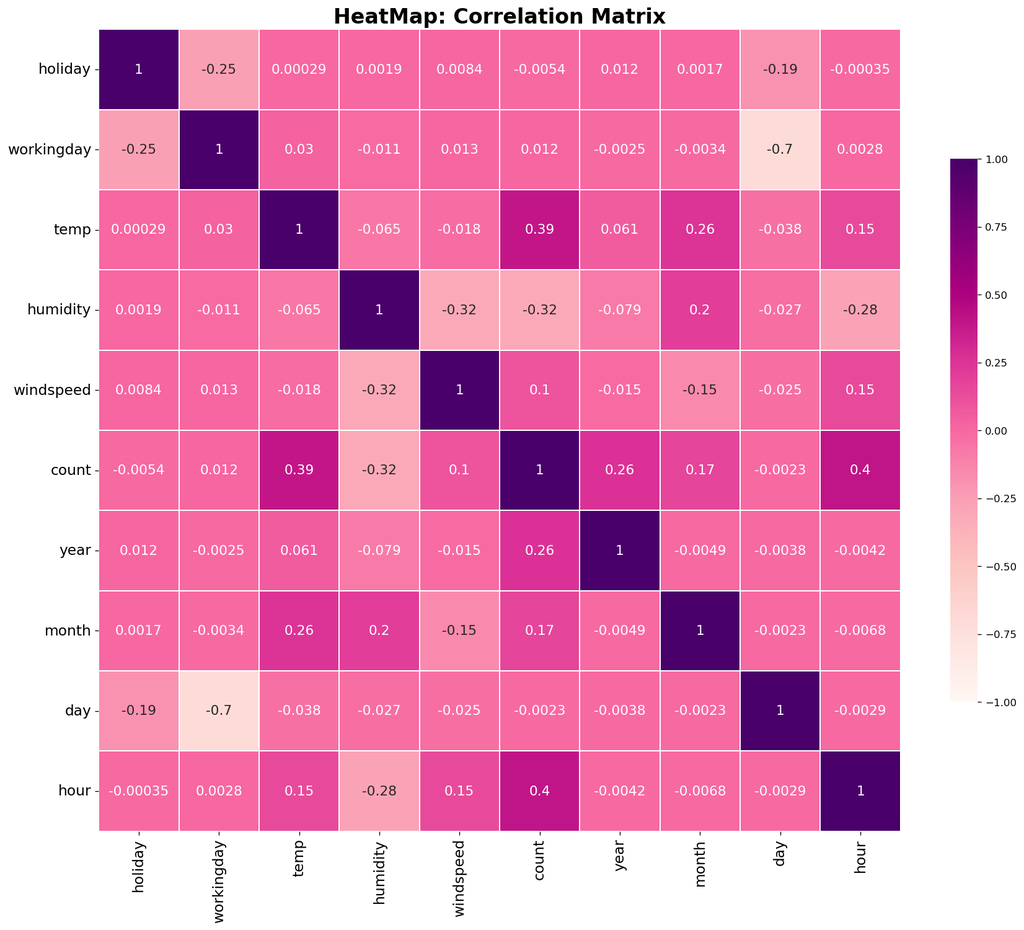

```python
import seaborn as sns
import numpy as np

# Select numeric features
feature_numeric = train.select_dtypes(include=np.number).columns.tolist()

# Exclude 'casual' and 'registered' features
feature_numeric = [i for i in feature_numeric if i not in ['casual', 'registered']]

# Generate correlation matrix
corr_matrix = train[feature_numeric].corr()

# Plot heatmap
plt.figure(figsize=(15, 15), dpi=120)
sns.heatmap(corr_matrix, cmap='RdPu', cbar_kws={"shrink": .5}, vmin=-1, vmax=1, center=0, square=True, annot=True, linewidths=0.01, annot_kws={"size": 13})
plt.xticks(fontsize=14, rotation=90)
plt.yticks(fontsize=14, rotation=0)
plt.title("HeatMap: Correlation Matrix", fontsize=20, fontweight='bold')
plt.tight_layout()
plt.show()
```

## Step 5: Rerun the model with the same settings as before, just with more features

```python
# Requirements: (Same settings as that of initial run) For AutoGluon's Tabular Predictions
eval_metric = 'root_mean_squared_error'
label = 'count'
ignored_columns = ["casual", "registered"]   # Ignored columns while training
train_data = train                           # 'casual' and 'registered' columns are already dropped/ignored
time_limit = 600                             # 10 minutes -> 60*10 = 600 seconds
presets = "best_quality"                     # auto_stack=True
```

```python
predictor_new_features = TabularPredictor(label=label,
                                          problem_type= 'regression',
                                          eval_metric=eval_metric,
                                          learner_kwargs={'ignored_columns': ignored_columns}).fit(
                                                                                           train_data = train_data,
                                                                                           time_limit=time_limit,
                                                                                           presets=presets)
```

```
No path specified. Models will be saved in: "AutogluonModels/ag-20240510_150054"
Presets specified: ['best_quality']
Stack configuration (auto_stack=True): num_stack_levels=1, num_bag_folds=8, num_bag_sets=20
Beginning AutoGluon training ... Time limit = 600s
AutoGluon will save models to "AutogluonModels/ag-20240510_150054"
AutoGluon Version:  0.8.2
Python Version:     3.10.14
Operating System:   Linux
Platform Machine:   x86_64
Platform Version:   #1 SMP Sat Mar 23 09:49:55 UTC 2024
Disk Space Avail:   3.40 GB / 5.36 GB (63.5%)
	WARNING: Available disk space is low and there is a risk that AutoGluon will run out of disk during fit, causing an exception.
	We recommend a minimum available disk space of 10 GB, and large datasets may require more.
Train Data Rows:    10886
Train Data Columns: 14
Label Column: count
Preprocessing data ...
Using Feature Generators to preprocess the data ...
Dropping user-specified ignored columns: ['casual', 'registered']
Fitting AutoMLPipelineFeatureGenerator...
	Available Memory:                    2088.39 MB
	Train Data (Original)  Memory Usage: 0.64 MB (0.0% of available memory)
	Inferring data type of each feature based on column values. Set feature_metadata_in to manually specify special dtypes of the features.
	Stage 1 Generators:
		Fitting AsTypeFeatureGenerator...
			Note: Converting 3 features to boolean dtype as they only contain 2 unique values.
	Stage 2 Generators:
		Fitting FillNaFeatureGenerator...
	Stage 3 Generators:
		Fitting IdentityFeatureGenerator...
		Fitting CategoryFeatureGenerator...
			Fitting CategoryMemoryMinimizeFeatureGenerator...
	Stage 4 Generators:
		Fitting DropUniqueFeatureGenerator...
	Stage 5 Generators:
		Fitting DropDuplicatesFeatureGenerator...
	Types of features in original data (raw dtype, special dtypes):
		('category', []) : 3 | ['season', 'weather', 'day_type']
		('float', [])    : 2 | ['temp', 'windspeed']
		('int', [])      : 7 | ['holiday', 'workingday', 'humidity', 'year', 'month', ...]
```

[output cut: 20 more lines]

```
	'XT': [{'criterion': 'gini', 'ag_args': {'name_suffix': 'Gini', 'problem_types': ['binary', 'multiclass']}}, {'criterion': 'entropy', 'ag_args': {'name_suffix': 'Entr', 'problem_types': ['binary', 'multiclass']}}, {'criterion': 'squared_error', 'ag_args': {'name_suffix': 'MSE', 'problem_types': ['r…
	'KNN': [{'weights': 'uniform', 'ag_args': {'name_suffix': 'Unif'}}, {'weights': 'distance', 'ag_args': {'name_suffix': 'Dist'}}],
}
AutoGluon will fit 2 stack levels (L1 to L2) ...
Fitting 11 L1 models ...
Fitting model: KNeighborsUnif_BAG_L1 ... Training model for up to 399.79s of the 599.83s of remaining time.
	-113.2616	 = Validation score   (-root_mean_squared_error)
	0.03s	 = Training   runtime
	0.15s	 = Validation runtime
Fitting model: KNeighborsDist_BAG_L1 ... Training model for up to 399.57s of the 599.61s of remaining time.
	-109.8452	 = Validation score   (-root_mean_squared_error)
	0.03s	 = Training   runtime
	0.16s	 = Validation runtime
Fitting model: LightGBMXT_BAG_L1 ... Training model for up to 399.34s of the 599.38s of remaining time.
	Fitting 8 child models (S1F1 - S1F8) | Fitting with SequentialLocalFoldFittingStrategy
```

[output not shown]

```
	-36.708	 = Validation score   (-root_mean_squared_error)
	63.47s	 = Training   runtime
	12.77s	 = Validation runtime
Fitting model: LightGBM_BAG_L1 ... Training model for up to 313.3s of the 513.34s of remaining time.
	Fitting 8 child models (S1F1 - S1F8) | Fitting with SequentialLocalFoldFittingStrategy
```

```
[1000]	valid_set's rmse: 34.8033
[1000]	valid_set's rmse: 34.3411
[1000]	valid_set's rmse: 35.127
[2000]	valid_set's rmse: 34.2862
[3000]	valid_set's rmse: 34.0877
[4000]	valid_set's rmse: 34.0513
[1000]	valid_set's rmse: 37.2947
[2000]	valid_set's rmse: 36.9622
[1000]	valid_set's rmse: 38.9758
[2000]	valid_set's rmse: 38.6611
[1000]	valid_set's rmse: 33.8549
[2000]	valid_set's rmse: 33.579
[3000]	valid_set's rmse: 33.612
[1000]	valid_set's rmse: 39.4167
[2000]	valid_set's rmse: 39.2548
[1000]	valid_set's rmse: 35.3623
[2000]	valid_set's rmse: 34.9849
```

```
	-35.7804	 = Validation score   (-root_mean_squared_error)
	24.71s	 = Training   runtime
	3.28s	 = Validation runtime
Fitting model: RandomForestMSE_BAG_L1 ... Training model for up to 281.69s of the 481.73s of remaining time.
	-39.7172	 = Validation score   (-root_mean_squared_error)
	13.43s	 = Training   runtime
	0.79s	 = Validation runtime
Fitting model: CatBoost_BAG_L1 ... Training model for up to 266.86s of the 466.9s of remaining time.
	Fitting 8 child models (S1F1 - S1F8) | Fitting with SequentialLocalFoldFittingStrategy
	Ran out of time, early stopping on iteration 2068.
	Ran out of time, early stopping on iteration 2165.
	Ran out of time, early stopping on iteration 2290.
	Ran out of time, early stopping on iteration 2364.
	Ran out of time, early stopping on iteration 2362.
	Ran out of time, early stopping on iteration 2470.
	Ran out of time, early stopping on iteration 2760.
	Ran out of time, early stopping on iteration 3213.
	-36.269	 = Validation score   (-root_mean_squared_error)
	255.87s	 = Training   runtime
	0.12s	 = Validation runtime
Fitting model: ExtraTreesMSE_BAG_L1 ... Training model for up to 10.72s of the 210.76s of remaining time.
	-38.5802	 = Validation score   (-root_mean_squared_error)
	7.68s	 = Training   runtime
	0.65s	 = Validation runtime
Fitting model: NeuralNetFastAI_BAG_L1 ... Training model for up to 1.86s of the 201.9s of remaining time.
	Fitting 8 child models (S1F1 - S1F8) | Fitting with SequentialLocalFoldFittingStrategy
	Time limit exceeded... Skipping NeuralNetFastAI_BAG_L1.
Fitting model: XGBoost_BAG_L1 ... Training model for up to 1.73s of the 201.77s of remaining time.
	Fitting 8 child models (S1F1 - S1F8) | Fitting with SequentialLocalFoldFittingStrategy
	Time limit exceeded... Skipping XGBoost_BAG_L1.
Fitting model: NeuralNetTorch_BAG_L1 ... Training model for up to 1.28s of the 201.32s of remaining time.
	Fitting 8 child models (S1F1 - S1F8) | Fitting with SequentialLocalFoldFittingStrategy
	Time limit exceeded... Skipping NeuralNetTorch_BAG_L1.
Fitting model: LightGBMLarge_BAG_L1 ... Training model for up to 1.16s of the 201.2s of remaining time.
	Fitting 8 child models (S1F1 - S1F8) | Fitting with SequentialLocalFoldFittingStrategy
	Ran out of time, early stopping on iteration 1. Best iteration is:
	[1]	valid_set's rmse: 176.876
	Time limit exceeded... Skipping LightGBMLarge_BAG_L1.
Completed 1/20 k-fold bagging repeats ...
Fitting model: WeightedEnsemble_L2 ... Training model for up to 360.0s of the 200.75s of remaining time.
```

[output cut: 36 more lines]

```
Fitting model: XGBoost_BAG_L2 ... Training model for up to 2.69s of the 2.68s of remaining time.
	Fitting 8 child models (S1F1 - S1F8) | Fitting with SequentialLocalFoldFittingStrategy
	-35.3896	 = Validation score   (-root_mean_squared_error)
	2.47s	 = Training   runtime
	0.14s	 = Validation runtime
Fitting model: NeuralNetTorch_BAG_L2 ... Training model for up to 0.03s of the 0.02s of remaining time.
	Fitting 8 child models (S1F1 - S1F8) | Fitting with SequentialLocalFoldFittingStrategy
	Time limit exceeded... Skipping NeuralNetTorch_BAG_L2.
Completed 1/20 k-fold bagging repeats ...
Fitting model: WeightedEnsemble_L3 ... Training model for up to 360.0s of the -0.15s of remaining time.
	-34.0449	 = Validation score   (-root_mean_squared_error)
	0.38s	 = Training   runtime
	0.0s	 = Validation runtime
AutoGluon training complete, total runtime = 600.56s ... Best model: "WeightedEnsemble_L3"
TabularPredictor saved. To load, use: predictor = TabularPredictor.load("AutogluonModels/ag-20240510_150054")
```

```python
predictor_new_features.fit_summary()
```

```
*** Summary of fit() ***
Estimated performance of each model:
                     model   score_val  pred_time_val    fit_time  pred_time_val_marginal  fit_time_marginal  stack_level  can_infer  fit_order
0      WeightedEnsemble_L3  -34.044896      19.132521  501.301877                0.000725           0.379475            3       True         16
1      WeightedEnsemble_L2  -34.240720      17.619864  365.509164                0.000693           0.358406            2       True          8
2          CatBoost_BAG_L2  -34.313327      18.000471  445.365967                0.065226          80.159633            2       True         12
3     ExtraTreesMSE_BAG_L2  -34.364912      18.712969  377.483228                0.777723          12.276894            2       True         13
4   NeuralNetFastAI_BAG_L2  -34.792632      18.288847  408.485875                0.353602          43.279541            2       True         14
5          LightGBM_BAG_L2  -34.904761      18.043254  374.284967                0.108008           9.078633            2       True         10
6   RandomForestMSE_BAG_L2  -35.054783      18.610600  403.285107                0.675354          38.078773            2       True         11
7        LightGBMXT_BAG_L2  -35.064276      18.236578  376.141421                0.301333          10.935087            2       True          9
8           XGBoost_BAG_L2  -35.389565      18.073055  367.672951                0.137809           2.466617            2       True         15
9          LightGBM_BAG_L1  -35.780355       3.283141   24.708083                3.283141          24.708083            1       True          4
10         CatBoost_BAG_L1  -36.268991       0.123688  255.867076                0.123688         255.867076            1       True          6
11       LightGBMXT_BAG_L1  -36.708020      12.765692   63.466549               12.765692          63.466549            1       True          3
12    ExtraTreesMSE_BAG_L1  -38.580226       0.653542    7.679062                0.653542           7.679062            1       True          7
13  RandomForestMSE_BAG_L1  -39.717239       0.793108   13.429987                0.793108          13.429987            1       True          5
14   KNeighborsDist_BAG_L1 -109.845172       0.163127    0.028164                0.163127           0.028164            1       True          2
15   KNeighborsUnif_BAG_L1 -113.261643       0.152948    0.027412                0.152948           0.027412            1       True          1
Number of models trained: 16
Types of models trained:
{'StackerEnsembleModel_RF', 'StackerEnsembleModel_XT', 'StackerEnsembleModel_LGB', 'StackerEnsembleModel_CatBoost', 'WeightedEnsembleModel', 'StackerEnsembleModel_XGBoost', 'StackerEnsembleModel_NNFastAiTabular', 'StackerEnsembleModel_KNN'}
Bagging used: True  (with 8 folds)
Multi-layer stack-ensembling used: True  (with 3 levels)
Feature Metadata (Processed):
(raw dtype, special dtypes):
('category', [])  : 3 | ['season', 'weather', 'day_type']
('float', [])     : 2 | ['temp', 'windspeed']
('int', [])       : 4 | ['humidity', 'month', 'day', 'hour']
('int', ['bool']) : 3 | ['holiday', 'workingday', 'year']
*** End of fit() summary ***
```

[output not shown]

[output cut: 151 more lines]

```
 1           8
 2          12
 3          13
 4          14
 5          10
 6          11
 7           9
 8          15
 9           4
 10          6
 11          3
 12          7
 13          5
 14          2
 15          1  }
```

```python
leaderboard_new_features_df = pd.DataFrame(predictor_new_features.leaderboard(silent=True))
leaderboard_new_features_df
```

|  | model | score_val | pred_time_val | fit_time | pred_time_val_marginal | fit_time_marginal | stack_level | can_infer | fit_order |
| --- | --- | --- | --- | --- | --- | --- | --- | --- | --- |
| 0 | WeightedEnsemble_L3 | -34.044896 | 19.132521 | 501.301877 | 0.000725 | 0.379475 | 3 | True | 16 |
| 1 | WeightedEnsemble_L2 | -34.240720 | 17.619864 | 365.509164 | 0.000693 | 0.358406 | 2 | True | 8 |
| 2 | CatBoost_BAG_L2 | -34.313327 | 18.000471 | 445.365967 | 0.065226 | 80.159633 | 2 | True | 12 |
| 3 | ExtraTreesMSE_BAG_L2 | -34.364912 | 18.712969 | 377.483228 | 0.777723 | 12.276894 | 2 | True | 13 |
| 4 | NeuralNetFastAI_BAG_L2 | -34.792632 | 18.288847 | 408.485875 | 0.353602 | 43.279541 | 2 | True | 14 |
| 5 | LightGBM_BAG_L2 | -34.904761 | 18.043254 | 374.284967 | 0.108008 | 9.078633 | 2 | True | 10 |
| 6 | RandomForestMSE_BAG_L2 | -35.054783 | 18.610600 | 403.285107 | 0.675354 | 38.078773 | 2 | True | 11 |
| 7 | LightGBMXT_BAG_L2 | -35.064276 | 18.236578 | 376.141421 | 0.301333 | 10.935087 | 2 | True | 9 |
| 8 | XGBoost_BAG_L2 | -35.389565 | 18.073055 | 367.672951 | 0.137809 | 2.466617 | 2 | True | 15 |
| 9 | LightGBM_BAG_L1 | -35.780355 | 3.283141 | 24.708083 | 3.283141 | 24.708083 | 1 | True | 4 |
| 10 | CatBoost_BAG_L1 | -36.268991 | 0.123688 | 255.867076 | 0.123688 | 255.867076 | 1 | True | 6 |
| 11 | LightGBMXT_BAG_L1 | -36.708020 | 12.765692 | 63.466549 | 12.765692 | 63.466549 | 1 | True | 3 |
| 12 | ExtraTreesMSE_BAG_L1 | -38.580226 | 0.653542 | 7.679062 | 0.653542 | 7.679062 | 1 | True | 7 |
| 13 | RandomForestMSE_BAG_L1 | -39.717239 | 0.793108 | 13.429987 | 0.793108 | 13.429987 | 1 | True | 5 |
| 14 | KNeighborsDist_BAG_L1 | -109.845172 | 0.163127 | 0.028164 | 0.163127 | 0.028164 | 1 | True | 2 |
| 15 | KNeighborsUnif_BAG_L1 | -113.261643 | 0.152948 | 0.027412 | 0.152948 | 0.027412 | 1 | True | 1 |

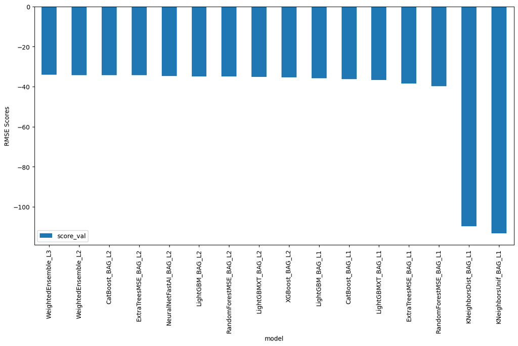

```python
# Output the model's `score_val` in a bar chart to compare performance
import matplotlib.pyplot as plt
leaderboard_new_features_df.plot(kind="bar", x="model", y="score_val", figsize=(14, 7))
plt.ylabel("RMSE Scores")
plt.show()
```

```python
predictions_new_features = predictor_new_features.predict(test)
predictions_new_features.head()
```

```
0    11.731040
1     6.290720
2     4.678907
3     3.878735
4     3.835050
Name: count, dtype: float32
```

```python
predictions_new_features.describe()
```

```
count    6493.000000
mean      189.852539
std       174.820648
min        -0.018119
25%        44.631641
50%       147.579880
75%       281.929993
max       901.409729
Name: count, dtype: float64
```

```python
# Remember to set all negative values to zero
negative_pred_count = predictions_new_features.apply(lambda x: 1 if x<0 else 0)

pred_pos_count = (negative_pred_count==0).sum()
pred_neg_count = (negative_pred_count==1).sum()

print("Total predictions                :", len(predictions_new_features.index))
print("Total positive prediction values :", pred_pos_count)
print("Total negative prediction values :", pred_neg_count)
predictions_new_features[predictions_new_features<0] = 0    # (In case, if negative values exist in the predictions_new_features, set them to 0)

# Rechecking, if no predictions are less than 0
negative_pred_count = predictions_new_features.apply(lambda x: 1 if x<0 else 0)
pred_neg_count = (negative_pred_count==1).sum()
print(f"No. of negative predictions: {pred_neg_count}")
print("All negative values in the predictions (if any) are set to zero successfully.")
```

```
Total predictions                : 6493
Total positive prediction values : 6492
Total negative prediction values : 1
No. of negative predictions: 0
All negative values in the predictions (if any) are set to zero successfully.
```

```python
# Same submitting predictions
submission_new_features = pd.read_csv('sampleSubmission.csv', parse_dates = ['datetime'])
submission_new_features.head()
```

|  | datetime | count |
| --- | --- | --- |
| 0 | 2011-01-20 00:00:00 | 0 |
| 1 | 2011-01-20 01:00:00 | 0 |
| 2 | 2011-01-20 02:00:00 | 0 |
| 3 | 2011-01-20 03:00:00 | 0 |
| 4 | 2011-01-20 04:00:00 | 0 |

```python
submission_new_features["count"] = predictions_new_features
submission_new_features.to_csv("submission_new_features.csv", index=False)
```

```python
!kaggle competitions submit -c bike-sharing-demand -f submission_new_features.csv -m "new features"
```

```
Successfully submitted to Bike Sharing Demand
```

```python
!kaggle competitions submissions -c bike-sharing-demand | tail -n +1 | head -n 6
```

```
fileName                     date                 description           status    publicScore  privateScore
---------------------------  -------------------  --------------------  --------  -----------  ------------
submission_new_features.csv  2024-05-10 15:17:14  new features          complete  0.44716      0.44716
submission.csv               2024-05-10 14:54:54  first raw submission  complete  1.79874      1.79874
```

#### New Score of `0.44716`

## Step 6: Hyper parameter optimization

- There are many options for hyper parameter optimization.
- Options are to change the AutoGluon higher level parameters or the individual model hyperparameters.
- The hyperparameters of the models themselves that are in AutoGluon. Those need the `hyperparameter` and `hyperparameter_tune_kwargs` arguments.

```python
eval_metric = 'root_mean_squared_error'
label = 'count'
ignored_columns = ["casual", "registered"]   # Ignored columns while training
train_data = train                           # 'casual' and 'registered' columns are already dropped/ignored
time_limit = 600                             # 10 minutes -> 60*10 = 600 seconds
presets = "optimize_for_deployment"
```

```python
import autogluon.core as ag
## From autogluon documentation

nn_options = {'num_epochs': 5,
              'learning_rate': ag.space.Real(1e-4, 1e-2, default=5e-4, log=True),
                    # learning rate used in training (real-valued hyperparameter searched on log-scale)
              'activation': ag.space.Categorical('relu', 'softrelu', 'tanh'),
                    # activation function used in NN (categorical hyperparameter, default = first entry)
              'dropout_prob': ag.space.Real(0.0, 0.5, default=0.1)}

gbm_options = [{'extra_trees': True,
                'num_boost_round': ag.space.Int(lower=100, upper=500, default=100),
                'num_leaves': ag.space.Int(lower=25, upper=64, default=36),
                'ag_args': {'name_suffix': 'XT'}}, {}, 'GBMLarge']

hyperparameters = {  # hyperparameters of each model type
                   'GBM': gbm_options,
                   'NN_TORCH': nn_options,
                  }

num_trials = 20            # Number of hyperparameter optimization trials you want to perform
search_strategy = 'auto'  # tune hyperparameters using Bayesian optimization routine with a local scheduler
scheduler = 'local'       # Local FIFO scheduler

hyperparameter_tune_kwargs = {
    'num_trials': num_trials,
    'scheduler' : scheduler,
    'searcher': search_strategy,
}

predictor_new_hpo = TabularPredictor(label='count', problem_type='regression', eval_metric='root_mean_squared_error',
                                    learner_kwargs={'ignored_columns': ignored_columns}).fit(
                                                                         train_data=train,
                                                                         time_limit=time_limit,
                                                                         presets=presets,
                                                                         hyperparameters=hyperparameters,
                                                                         hyperparameter_tune_kwargs=hyperparameter_tune_kwargs,
                                                                         refit_full='best')
```

[output not shown]

```
Fitted model: LightGBMXT/T1 ...
	-71.9711	 = Validation score   (-root_mean_squared_error)
	0.82s	 = Training   runtime
	0.08s	 = Validation runtime
Fitted model: LightGBMXT/T2 ...
	-45.8136	 = Validation score   (-root_mean_squared_error)
	1.12s	 = Training   runtime
	0.1s	 = Validation runtime
Fitted model: LightGBMXT/T3 ...
	-47.839	 = Validation score   (-root_mean_squared_error)
	1.31s	 = Training   runtime
	0.16s	 = Validation runtime
Fitted model: LightGBMXT/T4 ...
	-41.7586	 = Validation score   (-root_mean_squared_error)
	1.15s	 = Training   runtime
	0.1s	 = Validation runtime
Fitted model: LightGBMXT/T5 ...
	-66.7598	 = Validation score   (-root_mean_squared_error)
	0.94s	 = Training   runtime
	0.09s	 = Validation runtime
Fitted model: LightGBMXT/T6 ...
	-107.2717	 = Validation score   (-root_mean_squared_error)
	1.02s	 = Training   runtime
	0.08s	 = Validation runtime
Fitted model: LightGBMXT/T7 ...
	-45.7988	 = Validation score   (-root_mean_squared_error)
	0.75s	 = Training   runtime
	0.06s	 = Validation runtime
Fitted model: LightGBMXT/T8 ...
	-50.7601	 = Validation score   (-root_mean_squared_error)
	1.5s	 = Training   runtime
	0.23s	 = Validation runtime
Fitted model: LightGBMXT/T9 ...
	-125.5283	 = Validation score   (-root_mean_squared_error)
	0.73s	 = Training   runtime
	0.03s	 = Validation runtime
Fitted model: LightGBMXT/T10 ...
	-72.6449	 = Validation score   (-root_mean_squared_error)
	1.23s	 = Training   runtime
	0.17s	 = Validation runtime
```

[output cut: 26 more lines]

```
	0.91s	 = Training   runtime
	0.07s	 = Validation runtime
Fitted model: LightGBMXT/T18 ...
	-66.3853	 = Validation score   (-root_mean_squared_error)
	1.2s	 = Training   runtime
	0.14s	 = Validation runtime
Fitted model: LightGBMXT/T19 ...
	-86.0468	 = Validation score   (-root_mean_squared_error)
	0.91s	 = Training   runtime
	0.06s	 = Validation runtime
Fitted model: LightGBMXT/T20 ...
	-45.2717	 = Validation score   (-root_mean_squared_error)
	1.24s	 = Training   runtime
	0.12s	 = Validation runtime
Hyperparameter tuning model: LightGBM ... Tuning model for up to 134.96s of the 574.97s of remaining time.
```

[output not shown]

```
	Ran out of time, early stopping on iteration 4993. Best iteration is:
	[3928]	valid_set's rmse: 38.015
	Stopping HPO to satisfy time limit...
Fitted model: LightGBM/T1 ...
	-38.7749	 = Validation score   (-root_mean_squared_error)
	1.74s	 = Training   runtime
	0.28s	 = Validation runtime
Fitted model: LightGBM/T2 ...
	-39.278	 = Validation score   (-root_mean_squared_error)
	1.4s	 = Training   runtime
	0.06s	 = Validation runtime
Fitted model: LightGBM/T3 ...
	-39.6569	 = Validation score   (-root_mean_squared_error)
	2.53s	 = Training   runtime
	0.4s	 = Validation runtime
Fitted model: LightGBM/T4 ...
	-38.124	 = Validation score   (-root_mean_squared_error)
	10.03s	 = Training   runtime
	2.06s	 = Validation runtime
Fitted model: LightGBM/T5 ...
	-39.5392	 = Validation score   (-root_mean_squared_error)
	1.89s	 = Training   runtime
	0.18s	 = Validation runtime
Fitted model: LightGBM/T6 ...
	-39.0408	 = Validation score   (-root_mean_squared_error)
	4.2s	 = Training   runtime
	0.75s	 = Validation runtime
Fitted model: LightGBM/T7 ...
	-38.6204	 = Validation score   (-root_mean_squared_error)
	1.92s	 = Training   runtime
	0.13s	 = Validation runtime
Fitted model: LightGBM/T8 ...
	-39.6364	 = Validation score   (-root_mean_squared_error)
	1.95s	 = Training   runtime
	0.24s	 = Validation runtime
Fitted model: LightGBM/T9 ...
	-38.5911	 = Validation score   (-root_mean_squared_error)
	7.77s	 = Training   runtime
	1.1s	 = Validation runtime
Fitted model: LightGBM/T10 ...
```

[output cut: 18 more lines]

```
	1.9s	 = Validation runtime
Fitted model: LightGBM/T15 ...
	-39.2396	 = Validation score   (-root_mean_squared_error)
	10.9s	 = Training   runtime
	4.66s	 = Validation runtime
Fitted model: LightGBM/T16 ...
	-37.8443	 = Validation score   (-root_mean_squared_error)
	12.3s	 = Training   runtime
	2.8s	 = Validation runtime
Fitted model: LightGBM/T17 ...
	-38.015	 = Validation score   (-root_mean_squared_error)
	10.49s	 = Training   runtime
	2.86s	 = Validation runtime
Hyperparameter tuning model: NeuralNetTorch ... Tuning model for up to 134.96s of the 434.75s of remaining time.
Will use custom hpo logic because ray import failed. Reason: ray is required to train folds in parallel for TabularPredictor or HPO for MultiModalPredictor. A quick tip is to install via `pip install ray==2.6.3`
```

```
Fitted model: NeuralNetTorch/T1 ...
	-115.318	 = Validation score   (-root_mean_squared_error)
	2.31s	 = Training   runtime
	0.01s	 = Validation runtime
Fitted model: NeuralNetTorch/T2 ...
	-69.1741	 = Validation score   (-root_mean_squared_error)
	4.42s	 = Training   runtime
	0.03s	 = Validation runtime
Fitted model: NeuralNetTorch/T3 ...
	-91.5597	 = Validation score   (-root_mean_squared_error)
	3.11s	 = Training   runtime
	0.03s	 = Validation runtime
Fitted model: NeuralNetTorch/T4 ...
	-66.7986	 = Validation score   (-root_mean_squared_error)
	7.28s	 = Training   runtime
	0.08s	 = Validation runtime
Fitted model: NeuralNetTorch/T5 ...
	-140.1766	 = Validation score   (-root_mean_squared_error)
	9.68s	 = Training   runtime
	0.06s	 = Validation runtime
Fitted model: NeuralNetTorch/T6 ...
	-144.0203	 = Validation score   (-root_mean_squared_error)
	2.47s	 = Training   runtime
	0.04s	 = Validation runtime
Fitted model: NeuralNetTorch/T7 ...
	-141.8841	 = Validation score   (-root_mean_squared_error)
	3.82s	 = Training   runtime
	0.03s	 = Validation runtime
Fitted model: NeuralNetTorch/T8 ...
	-117.3056	 = Validation score   (-root_mean_squared_error)
	2.09s	 = Training   runtime
	0.01s	 = Validation runtime
Fitted model: NeuralNetTorch/T9 ...
	-144.8299	 = Validation score   (-root_mean_squared_error)
	3.37s	 = Training   runtime
	0.02s	 = Validation runtime
Fitted model: NeuralNetTorch/T10 ...
	-106.5409	 = Validation score   (-root_mean_squared_error)
	2.39s	 = Training   runtime
	0.02s	 = Validation runtime
```

[output cut: 114 more lines]

[output not shown]

```python
predictor_new_hpo.fit_summary()
```

```
*** Summary of fit() ***
Estimated performance of each model:
                 model  score_val  pred_time_val   fit_time  pred_time_val_marginal  fit_time_marginal  stack_level  can_infer  fit_order
0  WeightedEnsemble_L2 -37.704708       6.635384  33.139923                0.000404           0.401266            2       True          5
1         LightGBM/T16 -37.844296       2.801394  12.298146                2.801394          12.298146            1       True          2
2         LightGBM/T17 -38.014973       2.856649  10.487481                2.856649          10.487481            1       True          3
3         LightGBM/T13 -38.369670       0.944877   5.530291                0.944877           5.530291            1       True          1
4    NeuralNetTorch/T2 -69.174136       0.032060   4.422739                0.032060           4.422739            1       True          4
Number of models trained: 5
Types of models trained:
{'TabularNeuralNetTorchModel', 'LGBModel', 'WeightedEnsembleModel'}
Bagging used: False
Multi-layer stack-ensembling used: False
Feature Metadata (Processed):
(raw dtype, special dtypes):
('category', [])  : 3 | ['season', 'weather', 'day_type']
('float', [])     : 2 | ['temp', 'windspeed']
('int', [])       : 4 | ['humidity', 'month', 'day', 'hour']
('int', ['bool']) : 3 | ['holiday', 'workingday', 'year']
*** End of fit() summary ***
```

```
{'model_types': {'LightGBM/T13': 'LGBModel',
  'LightGBM/T16': 'LGBModel',
  'LightGBM/T17': 'LGBModel',
  'NeuralNetTorch/T2': 'TabularNeuralNetTorchModel',
  'WeightedEnsemble_L2': 'WeightedEnsembleModel'},
 'model_performance': {'LightGBM/T13': -38.3696701247306,
  'LightGBM/T16': -37.8442961045261,
  'LightGBM/T17': -38.014972867702795,
  'NeuralNetTorch/T2': -69.17413605274908,
  'WeightedEnsemble_L2': -37.70470782489886},
 'model_best': 'WeightedEnsemble_L2',
 'model_paths': {'LightGBM/T13': ['LightGBM', 'T13'],
  'LightGBM/T16': ['LightGBM', 'T16'],
  'LightGBM/T17': ['LightGBM', 'T17'],
  'NeuralNetTorch/T2': ['NeuralNetTorch', 'T2'],
  'WeightedEnsemble_L2': ['WeightedEnsemble_L2']},
 'model_fit_times': {'LightGBM/T13': 5.5302910804748535,
  'LightGBM/T16': 12.29814600944519,
  'LightGBM/T17': 10.487481355667114,
  'NeuralNetTorch/T2': 4.422738552093506,
  'WeightedEnsemble_L2': 0.40126562118530273},
 'model_pred_times': {'LightGBM/T13': 0.9448773860931396,
  'LightGBM/T16': 2.801393985748291,
  'LightGBM/T17': 2.8566486835479736,
  'NeuralNetTorch/T2': 0.03205990791320801,
  'WeightedEnsemble_L2': 0.00040411949157714844},
 'num_bag_folds': 0,
 'max_stack_level': 2,
 'model_hyperparams': {'LightGBM/T13': {'learning_rate': 0.011353825252123056,
   'feature_fraction': 0.7874187167959208,
   'min_data_in_leaf': 19,
   'num_leaves': 95},
  'LightGBM/T16': {'learning_rate': 0.00804484475314037,
   'feature_fraction': 0.8025956402684602,
   'min_data_in_leaf': 16,
   'num_leaves': 69},
  'LightGBM/T17': {'learning_rate': 0.005761424070803828,
   'feature_fraction': 0.8312618072520881,
   'min_data_in_leaf': 13,
   'num_leaves': 84},
```

[output cut: 31 more lines]

```
 4    NeuralNetTorch/T2 -69.174136       0.032060   4.422739

    pred_time_val_marginal  fit_time_marginal  stack_level  can_infer  \
 0                0.000404           0.401266            2       True
 1                2.801394          12.298146            1       True
 2                2.856649          10.487481            1       True
 3                0.944877           5.530291            1       True
 4                0.032060           4.422739            1       True

    fit_order
 0          5
 1          2
 2          3
 3          1
 4          4  }
```

```python
leaderboard_new_hpo_df = pd.DataFrame(predictor_new_hpo.leaderboard(silent=True))
leaderboard_new_hpo_df
```

|  | model | score_val | pred_time_val | fit_time | pred_time_val_marginal | fit_time_marginal | stack_level | can_infer | fit_order |
| --- | --- | --- | --- | --- | --- | --- | --- | --- | --- |
| 0 | WeightedEnsemble_L2 | -37.704708 | 6.635384 | 33.139923 | 0.000404 | 0.401266 | 2 | True | 5 |
| 1 | LightGBM/T16 | -37.844296 | 2.801394 | 12.298146 | 2.801394 | 12.298146 | 1 | True | 2 |
| 2 | LightGBM/T17 | -38.014973 | 2.856649 | 10.487481 | 2.856649 | 10.487481 | 1 | True | 3 |
| 3 | LightGBM/T13 | -38.369670 | 0.944877 | 5.530291 | 0.944877 | 5.530291 | 1 | True | 1 |
| 4 | NeuralNetTorch/T2 | -69.174136 | 0.032060 | 4.422739 | 0.032060 | 4.422739 | 1 | True | 4 |

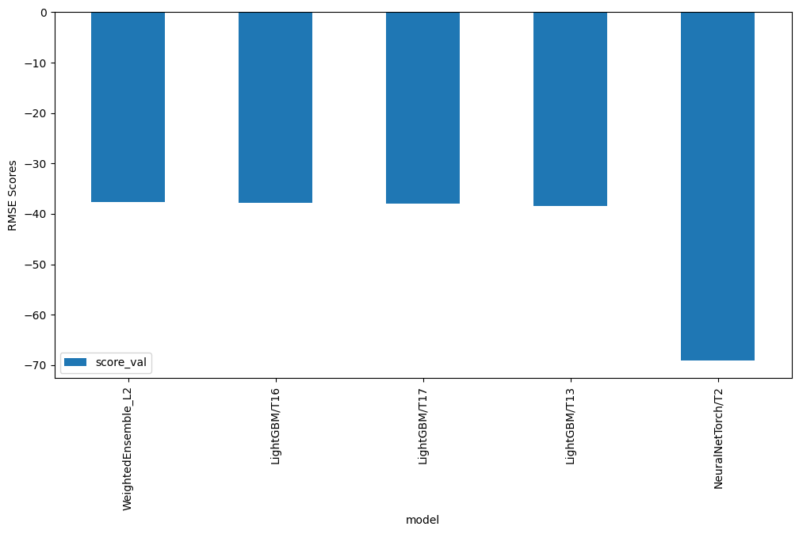

```python
import matplotlib.pyplot as plt
leaderboard_new_hpo_df.plot(kind="bar", x="model", y="score_val", figsize=(12, 6))
plt.ylabel("RMSE Scores")
plt.show()
```

```python
predictions_new_hpo = predictor_new_hpo.predict(test)
predictions_new_hpo.head()
```

```
0    18.856590
1     2.107190
2     0.196582
3     1.582138
4     1.600016
Name: count, dtype: float32
```

```python
predictions_new_hpo.describe()
```

```
count    6493.000000
mean      189.605652
std       173.744080
min       -30.098621
25%        46.631287
50%       147.080414
75%       283.871246
max       931.234741
Name: count, dtype: float64
```

```python
# Remember to set all negative values to zero
negative_pred_count = predictions_new_hpo.apply(lambda x: 1 if x<0 else 0)

pred_pos_count = (negative_pred_count==0).sum()
pred_neg_count = (negative_pred_count==1).sum()

print("Total predictions                :", len(predictions_new_hpo.index))
print("Total positive prediction values :", pred_pos_count)
print("Total negative prediction values :", pred_neg_count)
predictions_new_hpo[predictions_new_hpo<0] = 0    # (In case, if negative values exist in the predictions_new_hpo, set them to 0)

# Rechecking, if no predictions are less than 0
negative_pred_count = predictions_new_hpo.apply(lambda x: 1 if x<0 else 0)
pred_neg_count = (negative_pred_count==1).sum()
print(f"No. of negative predictions: {pred_neg_count}")
print("All negative values in the predictions (if any) are set to zero successfully.")
```

```
Total predictions                : 6493
Total positive prediction values : 6384
Total negative prediction values : 109
No. of negative predictions: 0
All negative values in the predictions (if any) are set to zero successfully.
```

```python
# Same submitting predictions
submission_new_hpo = pd.read_csv('sampleSubmission.csv', parse_dates = ['datetime'])
submission_new_hpo.head()
```

|  | datetime | count |
| --- | --- | --- |
| 0 | 2011-01-20 00:00:00 | 0 |
| 1 | 2011-01-20 01:00:00 | 0 |
| 2 | 2011-01-20 02:00:00 | 0 |
| 3 | 2011-01-20 03:00:00 | 0 |
| 4 | 2011-01-20 04:00:00 | 0 |

```python
submission_new_hpo["count"] = predictions_new_hpo
submission_new_hpo.to_csv("submission_new_hpo.csv", index=False)
```

```python
!kaggle competitions submit -c bike-sharing-demand -f submission_new_hpo.csv -m "new features with hyperparameters"
```

```
Successfully submitted to Bike Sharing Demand
```

```python
!kaggle competitions submissions -c bike-sharing-demand | tail -n +1 | head -n 6
```

```
fileName                     date                 description                        status    publicScore  privateScore
---------------------------  -------------------  ---------------------------------  --------  -----------  ------------
submission_new_hpo.csv       2024-05-10 15:26:18  new features with hyperparameters  complete  0.55594      0.55594
submission_new_features.csv  2024-05-10 15:17:14  new features                       complete  0.44716      0.44716
submission.csv               2024-05-10 14:54:54  first raw submission               complete  1.79874      1.79874
```

#### New Score of `0.55594`

```python
eval_metric = 'root_mean_squared_error'
label = 'count'
ignored_columns = ["casual", "registered"]   # Ignored columns while training
train_data = train                           # 'casual' and 'registered' columns are already dropped/ignored
time_limit = 600                             # 10 minutes -> 600 seconds
presets = "optimize_for_deployment"          # Lighter preset options (faster)
```

```python
import autogluon.core as ag
## From autogluon documentation:

# Exclude ['NN_TORCH'] family of models
excluded_model_types = ['NN_TORCH']


# Considering GBM, XT and XGB model types (as these along with WeightedEnsembles have shown good results)
# For GBM
gbm_options = [{'extra_trees': True,
                'num_boost_round': ag.space.Int(lower=100, upper=800, default=100),
                'num_leaves': ag.space.Int(lower=26, upper=66, default=36),  # number of leaves in trees (integer hyperparameter)
                'ag_args': {'name_suffix': 'XT'}}, {}, 'GBMLarge']

# XT Models
xt_options = {'criterion': 'squared_error', 'ag_args': {'name_suffix': 'MSE', 'problem_types': ['regression']}}

# XGB Models
xgb_options = [{'objective': 'reg:squarederror', # 'reg:linear' is deprecated
                'eval_metric': 'rmse',
                'max_depth':ag.space.Int(lower=5, upper=8, default=6),
                'n_estimators': ag.space.Int(lower=100, upper=500, default=100),
                'eta':.3,
                'subsample': 1,
                'colsample_bytree': 1}]

hyperparameters = {  # hyperparameters of each model type
                   'GBM': gbm_options,
                   'XT': xt_options,
                   'XGB': xgb_options
                  }

num_trials = 20            # Number of hyperparameter optimization trials you want to perform
search_strategy = 'auto'  # tune hyperparameters using Bayesian optimization routine with a local scheduler
scheduler = 'local'       # Local FIFO scheduler

hyperparameter_tune_kwargs = {
                            'num_trials': num_trials,
                            'scheduler' : scheduler,
                            'searcher': search_strategy,
                        }

predictor_new_hpo1 = TabularPredictor(label='count', problem_type='regression', eval_metric='root_mean_squared_error',
                                    learner_kwargs={'ignored_columns': ignored_columns}).fit(
                                                                         train_data=train,
                                                                         time_limit=time_limit,
                                                                         presets=presets,
                                                                         hyperparameters=hyperparameters,
                                                                         hyperparameter_tune_kwargs=hyperparameter_tune_kwargs,
                                                                         excluded_model_types=excluded_model_types,
                                                                         refit_full='best')
```

[output not shown]

```
Fitted model: LightGBMXT/T1 ...
	-71.9711	 = Validation score   (-root_mean_squared_error)
	0.76s	 = Training   runtime
	0.03s	 = Validation runtime
Fitted model: LightGBMXT/T2 ...
	-43.8633	 = Validation score   (-root_mean_squared_error)
	0.92s	 = Training   runtime
	0.09s	 = Validation runtime
Fitted model: LightGBMXT/T3 ...
	-88.1544	 = Validation score   (-root_mean_squared_error)
	0.91s	 = Training   runtime
	0.05s	 = Validation runtime
Fitted model: LightGBMXT/T4 ...
	-50.4195	 = Validation score   (-root_mean_squared_error)
	1.8s	 = Training   runtime
	0.3s	 = Validation runtime
Fitted model: LightGBMXT/T5 ...
	-90.0782	 = Validation score   (-root_mean_squared_error)
	0.66s	 = Training   runtime
	0.04s	 = Validation runtime
Fitted model: LightGBMXT/T6 ...
	-58.3299	 = Validation score   (-root_mean_squared_error)
	1.09s	 = Training   runtime
	0.11s	 = Validation runtime
Fitted model: LightGBMXT/T7 ...
	-40.3716	 = Validation score   (-root_mean_squared_error)
	1.84s	 = Training   runtime
	0.4s	 = Validation runtime
Fitted model: LightGBMXT/T8 ...
	-43.8404	 = Validation score   (-root_mean_squared_error)
	2.02s	 = Training   runtime
	0.36s	 = Validation runtime
Fitted model: LightGBMXT/T9 ...
	-52.6528	 = Validation score   (-root_mean_squared_error)
	1.54s	 = Training   runtime
	0.25s	 = Validation runtime
Fitted model: LightGBMXT/T10 ...
	-96.8619	 = Validation score   (-root_mean_squared_error)
	1.01s	 = Training   runtime
	0.07s	 = Validation runtime
```

[output cut: 26 more lines]

```
	1.47s	 = Training   runtime
	0.18s	 = Validation runtime
Fitted model: LightGBMXT/T18 ...
	-42.4013	 = Validation score   (-root_mean_squared_error)
	1.79s	 = Training   runtime
	0.26s	 = Validation runtime
Fitted model: LightGBMXT/T19 ...
	-95.0394	 = Validation score   (-root_mean_squared_error)
	1.24s	 = Training   runtime
	0.14s	 = Validation runtime
Fitted model: LightGBMXT/T20 ...
	-41.5532	 = Validation score   (-root_mean_squared_error)
	1.4s	 = Training   runtime
	0.26s	 = Validation runtime
Hyperparameter tuning model: LightGBM ... Tuning model for up to 107.97s of the 568.54s of remaining time.
```

[output not shown]

```
	Stopping HPO to satisfy time limit...
Fitted model: LightGBM/T1 ...
	-38.7749	 = Validation score   (-root_mean_squared_error)
	2.7s	 = Training   runtime
	0.46s	 = Validation runtime
Fitted model: LightGBM/T2 ...
	-39.278	 = Validation score   (-root_mean_squared_error)
	1.6s	 = Training   runtime
	0.1s	 = Validation runtime
Fitted model: LightGBM/T3 ...
	-39.6569	 = Validation score   (-root_mean_squared_error)
	2.91s	 = Training   runtime
	0.45s	 = Validation runtime
Fitted model: LightGBM/T4 ...
	-38.124	 = Validation score   (-root_mean_squared_error)
	11.26s	 = Training   runtime
	1.94s	 = Validation runtime
Fitted model: LightGBM/T5 ...
	-39.5392	 = Validation score   (-root_mean_squared_error)
	1.53s	 = Training   runtime
	0.25s	 = Validation runtime
Fitted model: LightGBM/T6 ...
	-39.0408	 = Validation score   (-root_mean_squared_error)
	3.44s	 = Training   runtime
	0.52s	 = Validation runtime
Fitted model: LightGBM/T7 ...
	-38.6204	 = Validation score   (-root_mean_squared_error)
	1.88s	 = Training   runtime
	0.2s	 = Validation runtime
Fitted model: LightGBM/T8 ...
	-39.6364	 = Validation score   (-root_mean_squared_error)
	1.39s	 = Training   runtime
	0.17s	 = Validation runtime
Fitted model: LightGBM/T9 ...
	-38.5911	 = Validation score   (-root_mean_squared_error)
	6.33s	 = Training   runtime
	1.42s	 = Validation runtime
Fitted model: LightGBM/T10 ...
	-38.5597	 = Validation score   (-root_mean_squared_error)
	1.18s	 = Training   runtime
```

[output cut: 13 more lines]

```
Fitted model: LightGBM/T14 ...
	-38.9827	 = Validation score   (-root_mean_squared_error)
	8.01s	 = Training   runtime
	1.86s	 = Validation runtime
Fitted model: LightGBM/T15 ...
	-39.2396	 = Validation score   (-root_mean_squared_error)
	12.63s	 = Training   runtime
	4.81s	 = Validation runtime
Hyperparameter tuning model: ExtraTreesMSE ... Tuning model for up to 107.97s of the 462.33s of remaining time.
	No hyperparameter search space specified for ExtraTreesMSE. Skipping HPO. Will train one model based on the provided hyperparameters.
Fitted model: ExtraTreesMSE ...
	-39.5841	 = Validation score   (-root_mean_squared_error)
	6.3s	 = Training   runtime
	0.89s	 = Validation runtime
Hyperparameter tuning model: XGBoost ... Tuning model for up to 107.97s of the 454.42s of remaining time.
```

```
Fitted model: XGBoost/T1 ...
	-41.7563	 = Validation score   (-root_mean_squared_error)
	0.36s	 = Training   runtime
	0.04s	 = Validation runtime
Fitted model: XGBoost/T2 ...
	-40.9482	 = Validation score   (-root_mean_squared_error)
	1.33s	 = Training   runtime
	0.11s	 = Validation runtime
Fitted model: XGBoost/T3 ...
	-40.1906	 = Validation score   (-root_mean_squared_error)
	1.77s	 = Training   runtime
	0.08s	 = Validation runtime
Fitted model: XGBoost/T4 ...
	-45.25	 = Validation score   (-root_mean_squared_error)
	0.59s	 = Training   runtime
	0.04s	 = Validation runtime
Fitted model: XGBoost/T5 ...
	-44.6192	 = Validation score   (-root_mean_squared_error)
	1.93s	 = Training   runtime
	0.08s	 = Validation runtime
Fitted model: XGBoost/T6 ...
	-40.6271	 = Validation score   (-root_mean_squared_error)
	2.77s	 = Training   runtime
	0.07s	 = Validation runtime
Fitted model: XGBoost/T7 ...
	-43.0461	 = Validation score   (-root_mean_squared_error)
	1.09s	 = Training   runtime
	0.06s	 = Validation runtime
Fitted model: XGBoost/T8 ...
	-39.3848	 = Validation score   (-root_mean_squared_error)
	2.41s	 = Training   runtime
	0.17s	 = Validation runtime
Fitted model: XGBoost/T9 ...
	-41.7707	 = Validation score   (-root_mean_squared_error)
	1.73s	 = Training   runtime
	0.13s	 = Validation runtime
Fitted model: XGBoost/T10 ...
	-40.1718	 = Validation score   (-root_mean_squared_error)
	1.67s	 = Training   runtime
	0.04s	 = Validation runtime
```

[output cut: 122 more lines]

[output not shown]

```python
predictor_new_hpo1.fit_summary()
```

```
*** Summary of fit() ***
Estimated performance of each model:
                 model  score_val  pred_time_val   fit_time  pred_time_val_marginal  fit_time_marginal  stack_level  can_infer  fit_order
0  WeightedEnsemble_L2 -37.329139       7.086833  40.070682                0.004390           0.446799            2       True          8
1          LightGBM/T4 -38.124006       1.941192  11.257523                1.941192          11.257523            1       True          1
2         LightGBM/T13 -38.369670       0.911573   5.280241                0.911573           5.280241            1       True          3
3         LightGBM/T12 -38.431862       2.835286  10.667941                2.835286          10.667941            1       True          2
4        LightGBMLarge -38.516436       0.268743   2.565692                0.268743           2.565692            1       True          7
5          XGBoost/T19 -38.740239       0.068103   1.143775                0.068103           1.143775            1       True          6
6           XGBoost/T8 -39.384803       0.170315   2.411787                0.170315           2.411787            1       True          5
7        ExtraTreesMSE -39.584076       0.887232   6.296923                0.887232           6.296923            1       True          4
Number of models trained: 8
Types of models trained:
{'XGBoostModel', 'LGBModel', 'XTModel', 'WeightedEnsembleModel'}
Bagging used: False
Multi-layer stack-ensembling used: False
Feature Metadata (Processed):
(raw dtype, special dtypes):
('category', [])  : 3 | ['season', 'weather', 'day_type']
('float', [])     : 2 | ['temp', 'windspeed']
('int', [])       : 4 | ['humidity', 'month', 'day', 'hour']
('int', ['bool']) : 3 | ['holiday', 'workingday', 'year']
*** End of fit() summary ***
```

```
{'model_types': {'LightGBM/T4': 'LGBModel',
  'LightGBM/T12': 'LGBModel',
  'LightGBM/T13': 'LGBModel',
  'ExtraTreesMSE': 'XTModel',
  'XGBoost/T8': 'XGBoostModel',
  'XGBoost/T19': 'XGBoostModel',
  'LightGBMLarge': 'LGBModel',
  'WeightedEnsemble_L2': 'WeightedEnsembleModel'},
 'model_performance': {'LightGBM/T4': -38.12400606131232,
  'LightGBM/T12': -38.431861570431245,
  'LightGBM/T13': -38.3696701247306,
  'ExtraTreesMSE': -39.584076050325685,
  'XGBoost/T8': -39.38480317646934,
  'XGBoost/T19': -38.7402388682388,
  'LightGBMLarge': -38.51643622165731,
  'WeightedEnsemble_L2': -37.329139013323804},
 'model_best': 'WeightedEnsemble_L2',
 'model_paths': {'LightGBM/T4': ['LightGBM', 'T4'],
  'LightGBM/T12': ['LightGBM', 'T12'],
  'LightGBM/T13': ['LightGBM', 'T13'],
  'ExtraTreesMSE': ['ExtraTreesMSE'],
  'XGBoost/T8': ['XGBoost', 'T8'],
  'XGBoost/T19': ['XGBoost', 'T19'],
  'LightGBMLarge': ['LightGBMLarge'],
  'WeightedEnsemble_L2': ['WeightedEnsemble_L2']},
 'model_fit_times': {'LightGBM/T4': 11.25752305984497,
  'LightGBM/T12': 10.667940616607666,
  'LightGBM/T13': 5.280241012573242,
  'ExtraTreesMSE': 6.2969231605529785,
  'XGBoost/T8': 2.411787271499634,
  'XGBoost/T19': 1.143775463104248,
  'LightGBMLarge': 2.5656917095184326,
  'WeightedEnsemble_L2': 0.44679927825927734},
 'model_pred_times': {'LightGBM/T4': 1.9411919116973877,
  'LightGBM/T12': 2.8352859020233154,
  'LightGBM/T13': 0.9115726947784424,
  'ExtraTreesMSE': 0.8872323036193848,
  'XGBoost/T8': 0.17031502723693848,
  'XGBoost/T19': 0.06810283660888672,
  'LightGBMLarge': 0.26874256134033203,
```

[output cut: 67 more lines]

```
 3                2.835286          10.667941            1       True
 4                0.268743           2.565692            1       True
 5                0.068103           1.143775            1       True
 6                0.170315           2.411787            1       True
 7                0.887232           6.296923            1       True

    fit_order
 0          8
 1          1
 2          3
 3          2
 4          7
 5          6
 6          5
 7          4  }
```

```python
leaderboard_new_hpo1_df = pd.DataFrame(predictor_new_hpo1.leaderboard(silent=True))
leaderboard_new_hpo1_df
```

|  | model | score_val | pred_time_val | fit_time | pred_time_val_marginal | fit_time_marginal | stack_level | can_infer | fit_order |
| --- | --- | --- | --- | --- | --- | --- | --- | --- | --- |
| 0 | WeightedEnsemble_L2 | -37.329139 | 7.086833 | 40.070682 | 0.004390 | 0.446799 | 2 | True | 8 |
| 1 | LightGBM/T4 | -38.124006 | 1.941192 | 11.257523 | 1.941192 | 11.257523 | 1 | True | 1 |
| 2 | LightGBM/T13 | -38.369670 | 0.911573 | 5.280241 | 0.911573 | 5.280241 | 1 | True | 3 |
| 3 | LightGBM/T12 | -38.431862 | 2.835286 | 10.667941 | 2.835286 | 10.667941 | 1 | True | 2 |
| 4 | LightGBMLarge | -38.516436 | 0.268743 | 2.565692 | 0.268743 | 2.565692 | 1 | True | 7 |
| 5 | XGBoost/T19 | -38.740239 | 0.068103 | 1.143775 | 0.068103 | 1.143775 | 1 | True | 6 |
| 6 | XGBoost/T8 | -39.384803 | 0.170315 | 2.411787 | 0.170315 | 2.411787 | 1 | True | 5 |
| 7 | ExtraTreesMSE | -39.584076 | 0.887232 | 6.296923 | 0.887232 | 6.296923 | 1 | True | 4 |

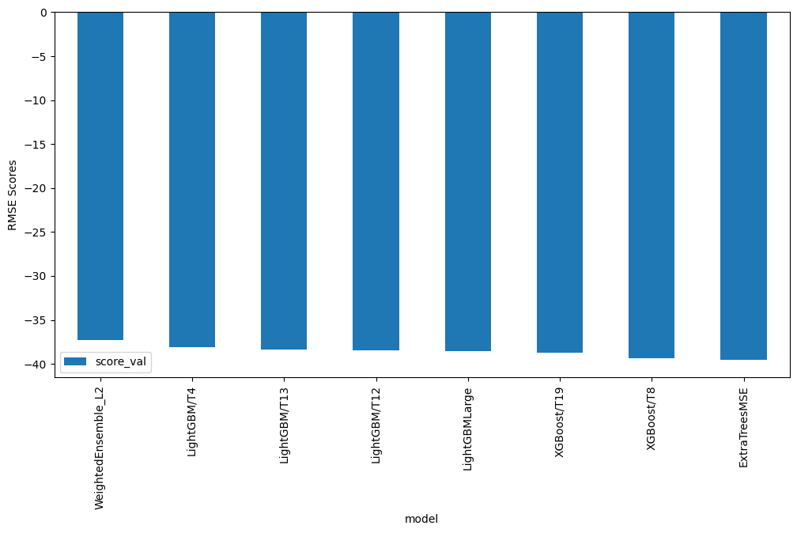

```python
import matplotlib.pyplot as plt
leaderboard_new_hpo1_df.plot(kind="bar", x="model", y="score_val", figsize=(12, 6))
plt.ylabel("RMSE Scores")
plt.show()
```

```python
predictions_new_hpo1 = predictor_new_hpo1.predict(test)
predictions_new_hpo1.head()
```

```
0    16.033894
1     3.644415
2     1.690593
3     1.489766
4     1.508111
Name: count, dtype: float32
```

```python
predictions_new_hpo1.describe()
```

```
count    6493.000000
mean      190.507812
std       173.572083
min       -12.272228
25%        46.968765
50%       149.752762
75%       283.867035
max       937.209473
Name: count, dtype: float64
```

```python
negative_pred_count = predictions_new_hpo1.apply(lambda x: 1 if x<0 else 0)

pred_pos_count = (negative_pred_count==0).sum()
pred_neg_count = (negative_pred_count==1).sum()

print("Total predictions                :", len(predictions_new_hpo1.index))
print("Total positive prediction values :", pred_pos_count)
print("Total negative prediction values :", pred_neg_count)
```

```
Total predictions                : 6493
Total positive prediction values : 6443
Total negative prediction values : 50
```

```python
predictions_new_hpo1[predictions_new_hpo1<0] = 0    # (In case, if negative values exist in the predictions_new_hpo1, set them to 0)

# Rechecking, if no predictions are less than 0
negative_pred_count = predictions_new_hpo1.apply(lambda x: 1 if x<0 else 0)
pred_neg_count = (negative_pred_count==1).sum()
print(f"No.of negative predictions: {pred_neg_count}")
print("All negative values in the predictions (if any) are set to zero successfully.")
```

```
No.of negative predictions: 0
All negative values in the predictions (if any) are set to zero successfully.
```

```python
submission_new_hpo1 = pd.read_csv('sampleSubmission.csv', parse_dates = ['datetime'])
submission_new_hpo1.head()
```

|  | datetime | count |
| --- | --- | --- |
| 0 | 2011-01-20 00:00:00 | 0 |
| 1 | 2011-01-20 01:00:00 | 0 |
| 2 | 2011-01-20 02:00:00 | 0 |
| 3 | 2011-01-20 03:00:00 | 0 |
| 4 | 2011-01-20 04:00:00 | 0 |

```python
submission_new_hpo1["count"] = predictions_new_hpo1
submission_new_hpo1.to_csv("submission_new_hpo1.csv", index=False)
```

```python
!kaggle competitions submit -c bike-sharing-demand -f submission_new_hpo1.csv -m "new features with hyperparameters 1"
```

```
Successfully submitted to Bike Sharing Demand
```

```python
!kaggle competitions submissions -c bike-sharing-demand | tail -n +1 | head -n 6
```

```
fileName                     date                 description                          status    publicScore  privateScore
---------------------------  -------------------  -----------------------------------  --------  -----------  ------------
submission_new_hpo1.csv      2024-05-10 15:36:01  new features with hyperparameters 1  complete  0.49469      0.49469
submission_new_hpo.csv       2024-05-10 15:26:18  new features with hyperparameters    complete  0.55594      0.55594
submission_new_features.csv  2024-05-10 15:17:14  new features                         complete  0.44716      0.44716
submission.csv               2024-05-10 14:54:54  first raw submission                 complete  1.79874      1.79874
```

#### New score is `0.49469`

```python
eval_metric = 'root_mean_squared_error'
label = 'count'
ignored_columns = ["casual", "registered"]   # Ignored columns while training
train_data = train                           # 'casual' and 'registered' columns are already dropped/ignored
time_limit = 600                             # 10 minutes -> 600 seconds
presets = "optimize_for_deployment"
```

```python
import autogluon.core as ag
## From autogluon documentation

# Exclude ['NN_TORCH'] family of models
excluded_model_types = ['NN_TORCH']


# Considering GBM, XT, XGB, KNN and RF model types (as these along with WeightedEnsembles have shown good results in the past)
# For GBM
gbm_options = [{'extra_trees': True,
                'num_boost_round': ag.space.Int(lower=100, upper=800, default=100),
                'num_leaves': ag.space.Int(lower=26, upper=66, default=36),  # number of leaves in trees (integer hyperparameter)
                'ag_args': {'name_suffix': 'XT'}}, {}, 'GBMLarge']
# XT Models
xt_options = {'criterion': 'squared_error', 'ag_args': {'name_suffix': 'MSE', 'problem_types': ['regression']}}
# XGB Models
xgb_options = [{'objective': 'reg:squarederror', # 'reg:linear' is deprecated
                'eval_metric': 'rmse',
                'max_depth':ag.space.Int(lower=5, upper=8, default=6),
                'n_estimators': ag.space.Int(lower=100, upper=500, default=100),
                'eta':.3,
                'subsample': 1,
                'colsample_bytree': 1}]
# Random Forest Models
rf_options = {'criterion': 'squared_error', 'ag_args': {'name_suffix': 'MSE', 'problem_types': ['regression']}}
# KNN
knn_options = [{'weights': 'uniform', 'ag_args': {'name_suffix': 'Uniform'}},
               {'weights': 'distance', 'ag_args': {'name_suffix': 'Distance'}}]  # default

hyperparameters = {  # hyperparameters of each model type
                   'GBM': gbm_options,
                   'KNN': knn_options,
                   'XT': xt_options,
                   'XGB': xgb_options,
                   'RF': rf_options
                  }


num_trials = 20            # Number of hyperparameter optimization trials you want to perform
search_strategy = 'auto'  # tune hyperparameters using Bayesian optimization routine with a local scheduler
scheduler = 'local'       # Local FIFO scheduler

hyperparameter_tune_kwargs = {
                            'num_trials': num_trials,
                            'scheduler' : scheduler,
                            'searcher': search_strategy,
                        }


predictor_new_hpo2 = TabularPredictor(label='count', problem_type='regression', eval_metric='root_mean_squared_error',
                                    learner_kwargs={'ignored_columns': ignored_columns}).fit(
                                                                         train_data=train,
                                                                         time_limit=time_limit,
                                                                         presets=presets,
                                                                         hyperparameters=hyperparameters,
                                                                         hyperparameter_tune_kwargs=hyperparameter_tune_kwargs,
                                                                         excluded_model_types=excluded_model_types,
                                                                         refit_full='best')
```

[output not shown]

[output cut: 21 more lines]

```
Excluded models: [] (Specified by `excluded_model_types`)
Fitting 8 L1 models ...
Hyperparameter tuning model: KNeighborsUniform ... Tuning model for up to 67.48s of the 599.86s of remaining time.
	No hyperparameter search space specified for KNeighborsUniform. Skipping HPO. Will train one model based on the provided hyperparameters.
Fitted model: KNeighborsUniform ...
	-115.323	 = Validation score   (-root_mean_squared_error)
	0.02s	 = Training   runtime
	0.18s	 = Validation runtime
Hyperparameter tuning model: KNeighborsDistance ... Tuning model for up to 67.48s of the 599.64s of remaining time.
	No hyperparameter search space specified for KNeighborsDistance. Skipping HPO. Will train one model based on the provided hyperparameters.
Fitted model: KNeighborsDistance ...
	-112.1867	 = Validation score   (-root_mean_squared_error)
	0.01s	 = Training   runtime
	0.12s	 = Validation runtime
Hyperparameter tuning model: LightGBMXT ... Tuning model for up to 67.48s of the 599.48s of remaining time.
```

```
Fitted model: LightGBMXT/T1 ...
	-71.9711	 = Validation score   (-root_mean_squared_error)
	0.83s	 = Training   runtime
	0.05s	 = Validation runtime
Fitted model: LightGBMXT/T2 ...
	-43.8633	 = Validation score   (-root_mean_squared_error)
	1.32s	 = Training   runtime
	0.16s	 = Validation runtime
Fitted model: LightGBMXT/T3 ...
	-88.1544	 = Validation score   (-root_mean_squared_error)
	0.8s	 = Training   runtime
	0.05s	 = Validation runtime
Fitted model: LightGBMXT/T4 ...
	-50.4195	 = Validation score   (-root_mean_squared_error)
	2.4s	 = Training   runtime
	0.39s	 = Validation runtime
Fitted model: LightGBMXT/T5 ...
	-90.0782	 = Validation score   (-root_mean_squared_error)
	1.0s	 = Training   runtime
	0.04s	 = Validation runtime
Fitted model: LightGBMXT/T6 ...
	-58.3299	 = Validation score   (-root_mean_squared_error)
	1.4s	 = Training   runtime
	0.18s	 = Validation runtime
Fitted model: LightGBMXT/T7 ...
	-40.3716	 = Validation score   (-root_mean_squared_error)
	2.35s	 = Training   runtime
	0.34s	 = Validation runtime
Fitted model: LightGBMXT/T8 ...
	-43.8404	 = Validation score   (-root_mean_squared_error)
	2.23s	 = Training   runtime
	0.49s	 = Validation runtime
Fitted model: LightGBMXT/T9 ...
	-52.6528	 = Validation score   (-root_mean_squared_error)
	1.54s	 = Training   runtime
	0.24s	 = Validation runtime
Fitted model: LightGBMXT/T10 ...
	-96.8619	 = Validation score   (-root_mean_squared_error)
	0.98s	 = Training   runtime
	0.12s	 = Validation runtime
```

[output cut: 26 more lines]

```
	1.58s	 = Training   runtime
	0.19s	 = Validation runtime
Fitted model: LightGBMXT/T18 ...
	-42.4013	 = Validation score   (-root_mean_squared_error)
	1.92s	 = Training   runtime
	0.36s	 = Validation runtime
Fitted model: LightGBMXT/T19 ...
	-95.0394	 = Validation score   (-root_mean_squared_error)
	1.43s	 = Training   runtime
	0.22s	 = Validation runtime
Fitted model: LightGBMXT/T20 ...
	-41.5532	 = Validation score   (-root_mean_squared_error)
	1.44s	 = Training   runtime
	0.21s	 = Validation runtime
Hyperparameter tuning model: LightGBM ... Tuning model for up to 67.48s of the 562.72s of remaining time.
```

[output not shown]

```
	Ran out of time, early stopping on iteration 1089. Best iteration is:
	[1089]	valid_set's rmse: 39.0747
```

```
[1000]	valid_set's rmse: 39.1305
```

```
	Stopping HPO to satisfy time limit...
Fitted model: LightGBM/T1 ...
	-38.7749	 = Validation score   (-root_mean_squared_error)
	2.86s	 = Training   runtime
	0.6s	 = Validation runtime
Fitted model: LightGBM/T2 ...
	-39.278	 = Validation score   (-root_mean_squared_error)
	1.69s	 = Training   runtime
	0.18s	 = Validation runtime
Fitted model: LightGBM/T3 ...
	-39.6569	 = Validation score   (-root_mean_squared_error)
	3.44s	 = Training   runtime
	0.36s	 = Validation runtime
Fitted model: LightGBM/T4 ...
	-38.124	 = Validation score   (-root_mean_squared_error)
	11.39s	 = Training   runtime
	3.4s	 = Validation runtime
Fitted model: LightGBM/T5 ...
	-39.5392	 = Validation score   (-root_mean_squared_error)
	2.65s	 = Training   runtime
	0.25s	 = Validation runtime
Fitted model: LightGBM/T6 ...
	-39.0408	 = Validation score   (-root_mean_squared_error)
	4.28s	 = Training   runtime
	0.92s	 = Validation runtime
Fitted model: LightGBM/T7 ...
	-38.6204	 = Validation score   (-root_mean_squared_error)
	1.92s	 = Training   runtime
	0.12s	 = Validation runtime
Fitted model: LightGBM/T8 ...
	-39.6364	 = Validation score   (-root_mean_squared_error)
	2.48s	 = Training   runtime
	0.21s	 = Validation runtime
Fitted model: LightGBM/T9 ...
	-38.5911	 = Validation score   (-root_mean_squared_error)
	6.66s	 = Training   runtime
	1.81s	 = Validation runtime
Fitted model: LightGBM/T10 ...
	-38.5597	 = Validation score   (-root_mean_squared_error)
	1.23s	 = Training   runtime
	0.05s	 = Validation runtime
Fitted model: LightGBM/T11 ...
	-38.2283	 = Validation score   (-root_mean_squared_error)
	4.87s	 = Training   runtime
	1.02s	 = Validation runtime
Fitted model: LightGBM/T12 ...
	-39.0747	 = Validation score   (-root_mean_squared_error)
	2.99s	 = Training   runtime
	0.56s	 = Validation runtime
Hyperparameter tuning model: RandomForestMSE ... Tuning model for up to 67.48s of the 497.42s of remaining time.
	No hyperparameter search space specified for RandomForestMSE. Skipping HPO. Will train one model based on the provided hyperparameters.
Fitted model: RandomForestMSE ...
	-41.0484	 = Validation score   (-root_mean_squared_error)
	10.82s	 = Training   runtime
	0.81s	 = Validation runtime
Hyperparameter tuning model: ExtraTreesMSE ... Tuning model for up to 67.48s of the 485.02s of remaining time.
	No hyperparameter search space specified for ExtraTreesMSE. Skipping HPO. Will train one model based on the provided hyperparameters.
Fitted model: ExtraTreesMSE ...
	-39.5841	 = Validation score   (-root_mean_squared_error)
	6.8s	 = Training   runtime
	1.01s	 = Validation runtime
Hyperparameter tuning model: XGBoost ... Tuning model for up to 67.48s of the 476.31s of remaining time.
```

```
Fitted model: XGBoost/T1 ...
	-41.7563	 = Validation score   (-root_mean_squared_error)
	0.65s	 = Training   runtime
	0.03s	 = Validation runtime
Fitted model: XGBoost/T2 ...
	-40.9482	 = Validation score   (-root_mean_squared_error)
	2.78s	 = Training   runtime
	0.17s	 = Validation runtime
Fitted model: XGBoost/T3 ...
	-40.1906	 = Validation score   (-root_mean_squared_error)
	1.67s	 = Training   runtime
	0.06s	 = Validation runtime
Fitted model: XGBoost/T4 ...
	-45.25	 = Validation score   (-root_mean_squared_error)
	0.88s	 = Training   runtime
	0.04s	 = Validation runtime
Fitted model: XGBoost/T5 ...
	-44.6192	 = Validation score   (-root_mean_squared_error)
	2.25s	 = Training   runtime
	0.17s	 = Validation runtime
Fitted model: XGBoost/T6 ...
	-40.6271	 = Validation score   (-root_mean_squared_error)
	1.86s	 = Training   runtime
	0.06s	 = Validation runtime
Fitted model: XGBoost/T7 ...
	-43.0461	 = Validation score   (-root_mean_squared_error)
	1.23s	 = Training   runtime
	0.04s	 = Validation runtime
Fitted model: XGBoost/T8 ...
	-39.3848	 = Validation score   (-root_mean_squared_error)
	2.09s	 = Training   runtime
	0.18s	 = Validation runtime
Fitted model: XGBoost/T9 ...
	-41.7707	 = Validation score   (-root_mean_squared_error)
	1.65s	 = Training   runtime
	0.1s	 = Validation runtime
Fitted model: XGBoost/T10 ...
	-40.1718	 = Validation score   (-root_mean_squared_error)
	1.59s	 = Training   runtime
	0.04s	 = Validation runtime
```

[output cut: 119 more lines]

[output not shown]

```python
predictor_new_hpo2.fit_summary()
```

```
*** Summary of fit() ***
Estimated performance of each model:
                 model  score_val  pred_time_val   fit_time  pred_time_val_marginal  fit_time_marginal  stack_level  can_infer  fit_order
0  WeightedEnsemble_L2 -37.141850       5.134284  27.184108                0.000622           0.605504            2       True          7
1          LightGBM/T4 -38.124006       3.401982  11.388109                3.401982          11.388109            1       True          1
2        LightGBMLarge -38.516436       0.374756   3.796447                0.374756           3.796447            1       True          6
3         LightGBM/T10 -38.559673       0.054946   1.225734                0.054946           1.225734            1       True          2
4          XGBoost/T19 -38.740239       0.109675   1.280316                0.109675           1.280316            1       True          5
5           XGBoost/T8 -39.384803       0.181603   2.090572                0.181603           2.090572            1       True          4
6        ExtraTreesMSE -39.584076       1.010700   6.797426                1.010700           6.797426            1       True          3
Number of models trained: 7
Types of models trained:
{'XGBoostModel', 'LGBModel', 'XTModel', 'WeightedEnsembleModel'}
Bagging used: False
Multi-layer stack-ensembling used: False
Feature Metadata (Processed):
(raw dtype, special dtypes):
('category', [])  : 3 | ['season', 'weather', 'day_type']
('float', [])     : 2 | ['temp', 'windspeed']
('int', [])       : 4 | ['humidity', 'month', 'day', 'hour']
('int', ['bool']) : 3 | ['holiday', 'workingday', 'year']
*** End of fit() summary ***
```

```
{'model_types': {'LightGBM/T4': 'LGBModel',
  'LightGBM/T10': 'LGBModel',
  'ExtraTreesMSE': 'XTModel',
  'XGBoost/T8': 'XGBoostModel',
  'XGBoost/T19': 'XGBoostModel',
  'LightGBMLarge': 'LGBModel',
  'WeightedEnsemble_L2': 'WeightedEnsembleModel'},
 'model_performance': {'LightGBM/T4': -38.12400606131232,
  'LightGBM/T10': -38.55967268294494,
  'ExtraTreesMSE': -39.584076050325685,
  'XGBoost/T8': -39.38480317646934,
  'XGBoost/T19': -38.7402388682388,
  'LightGBMLarge': -38.51643622165731,
  'WeightedEnsemble_L2': -37.14184978735763},
 'model_best': 'WeightedEnsemble_L2',
 'model_paths': {'LightGBM/T4': ['LightGBM', 'T4'],
  'LightGBM/T10': ['LightGBM', 'T10'],
  'ExtraTreesMSE': ['ExtraTreesMSE'],
  'XGBoost/T8': ['XGBoost', 'T8'],
  'XGBoost/T19': ['XGBoost', 'T19'],
  'LightGBMLarge': ['LightGBMLarge'],
  'WeightedEnsemble_L2': ['WeightedEnsemble_L2']},
 'model_fit_times': {'LightGBM/T4': 11.38810920715332,
  'LightGBM/T10': 1.225733995437622,
  'ExtraTreesMSE': 6.797425746917725,
  'XGBoost/T8': 2.090571880340576,
  'XGBoost/T19': 1.2803161144256592,
  'LightGBMLarge': 3.796447277069092,
  'WeightedEnsemble_L2': 0.6055035591125488},
 'model_pred_times': {'LightGBM/T4': 3.401982069015503,
  'LightGBM/T10': 0.0549464225769043,
  'ExtraTreesMSE': 1.0107002258300781,
  'XGBoost/T8': 0.18160271644592285,
  'XGBoost/T19': 0.10967516899108887,
  'LightGBMLarge': 0.3747556209564209,
  'WeightedEnsemble_L2': 0.0006222724914550781},
 'num_bag_folds': 0,
 'max_stack_level': 2,
 'model_hyperparams': {'LightGBM/T4': {'learning_rate': 0.006163502781172818,
   'feature_fraction': 0.824383651636118,
```

[output cut: 55 more lines]

```
 1                3.401982          11.388109            1       True
 2                0.374756           3.796447            1       True
 3                0.054946           1.225734            1       True
 4                0.109675           1.280316            1       True
 5                0.181603           2.090572            1       True
 6                1.010700           6.797426            1       True

    fit_order
 0          7
 1          1
 2          6
 3          2
 4          5
 5          4
 6          3  }
```

```python
leaderboard_new_hpo2_df = pd.DataFrame(predictor_new_hpo2.leaderboard(silent=True))
leaderboard_new_hpo2_df
```

|  | model | score_val | pred_time_val | fit_time | pred_time_val_marginal | fit_time_marginal | stack_level | can_infer | fit_order |
| --- | --- | --- | --- | --- | --- | --- | --- | --- | --- |
| 0 | WeightedEnsemble_L2 | -37.141850 | 5.134284 | 27.184108 | 0.000622 | 0.605504 | 2 | True | 7 |
| 1 | LightGBM/T4 | -38.124006 | 3.401982 | 11.388109 | 3.401982 | 11.388109 | 1 | True | 1 |
| 2 | LightGBMLarge | -38.516436 | 0.374756 | 3.796447 | 0.374756 | 3.796447 | 1 | True | 6 |
| 3 | LightGBM/T10 | -38.559673 | 0.054946 | 1.225734 | 0.054946 | 1.225734 | 1 | True | 2 |
| 4 | XGBoost/T19 | -38.740239 | 0.109675 | 1.280316 | 0.109675 | 1.280316 | 1 | True | 5 |
| 5 | XGBoost/T8 | -39.384803 | 0.181603 | 2.090572 | 0.181603 | 2.090572 | 1 | True | 4 |
| 6 | ExtraTreesMSE | -39.584076 | 1.010700 | 6.797426 | 1.010700 | 6.797426 | 1 | True | 3 |

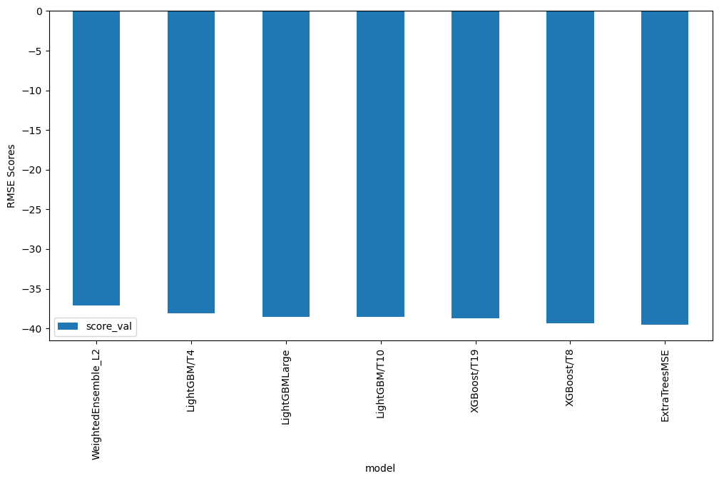

```python
import matplotlib.pyplot as plt
leaderboard_new_hpo2_df.plot(kind="bar", x="model", y="score_val", figsize=(12, 6))
plt.ylabel("RMSE Scores")
plt.show()
```

```python
predictions_new_hpo2 = predictor_new_hpo2.predict(test)
predictions_new_hpo2.head()
```

```
0    17.237869
1     3.923938
2     2.185165
3     1.610111
4     1.638256
Name: count, dtype: float32
```

```python
predictions_new_hpo2.describe()
```

```
count    6493.000000
mean      190.539291
std       173.845673
min       -14.567701
25%        46.713356
50%       148.843399
75%       283.404480
max       939.507935
Name: count, dtype: float64
```

```python
negative_pred_count = predictions_new_hpo2.apply(lambda x: 1 if x<0 else 0)

pred_pos_count = (negative_pred_count==0).sum()
pred_neg_count = (negative_pred_count==1).sum()

print("Total predictions                :", len(predictions_new_hpo2.index))
print("Total positive prediction values :", pred_pos_count)
print("Total negative prediction values :", pred_neg_count)
```

```
Total predictions                : 6493
Total positive prediction values : 6442
Total negative prediction values : 51
```

```python
predictions_new_hpo2[predictions_new_hpo2<0] = 0    # (In case, if negative values exist in the predictions_new_hpo2, set them to 0)

# Rechecking, if no predictions are less than 0
negative_pred_count = predictions_new_hpo2.apply(lambda x: 1 if x<0 else 0)
pred_neg_count = (negative_pred_count==1).sum()
print(f"No. of negative predictions: {pred_neg_count}")
print("All negative values in the predictions (if any) are set to zero successfully.")
```

```
No. of negative predictions: 0
All negative values in the predictions (if any) are set to zero successfully.
```

```python
submission_new_hpo2 = pd.read_csv('sampleSubmission.csv', parse_dates = ['datetime'])
submission_new_hpo2.head()
```

|  | datetime | count |
| --- | --- | --- |
| 0 | 2011-01-20 00:00:00 | 0 |
| 1 | 2011-01-20 01:00:00 | 0 |
| 2 | 2011-01-20 02:00:00 | 0 |
| 3 | 2011-01-20 03:00:00 | 0 |
| 4 | 2011-01-20 04:00:00 | 0 |

```python
submission_new_hpo2["count"] = predictions_new_hpo2
submission_new_hpo2.to_csv("submission_new_hpo2.csv", index=False)
```

```python
!kaggle competitions submit -c bike-sharing-demand -f submission_new_hpo2.csv -m "new features with hyperparameters 2"
```

```
Successfully submitted to Bike Sharing Demand
```

```python
!kaggle competitions submissions -c bike-sharing-demand | tail -n +1 | head -n 7
```

```
fileName                     date                 description                          status    publicScore  privateScore
---------------------------  -------------------  -----------------------------------  --------  -----------  ------------
submission_new_hpo2.csv      2024-05-10 15:46:21  new features with hyperparameters 2  complete  0.49927      0.49927
submission_new_hpo1.csv      2024-05-10 15:36:01  new features with hyperparameters 1  complete  0.49469      0.49469
submission_new_hpo.csv       2024-05-10 15:26:18  new features with hyperparameters    complete  0.55594      0.55594
submission_new_features.csv  2024-05-10 15:17:14  new features                         complete  0.44716      0.44716
submission.csv               2024-05-10 14:54:54  first raw submission                 complete  1.79874      1.79874
```

#### New Score is `0.49927`

## Step 7: Write a Report

### Refer to the markdown file for the full report

### Creating plots and table for report

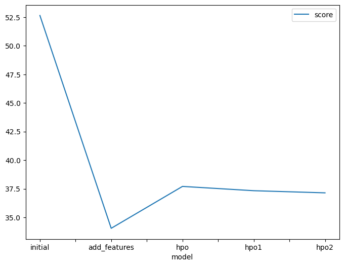

```python
# Taking the top model score from each training run and creating a line plot to show improvement
# You can create these in the notebook and save them to PNG or use some other tool (e.g. google sheets, excel)
fig = pd.DataFrame(
    {
        "model": ["initial", "add_features", "hpo", "hpo1", "hpo2"],
        "score": [52.6369, 34.0449, 37.7047, 37.3291, 37.1418]
    }
).plot(x="model", y="score", figsize=(8, 6)).get_figure()
fig.savefig('model_train_score.png')
```

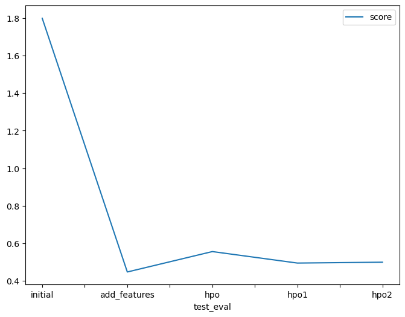

```python
# Take the 3 kaggle scores and creating a line plot to show improvement
fig = pd.DataFrame(
    {
        "test_eval": ["initial", "add_features", "hpo", "hpo1", "hpo2"],
        "score": [1.79874, 0.44716, 0.55594, 0.49469, 0.49927]
    }
).plot(x="test_eval", y="score", figsize=(8, 6)).get_figure()
fig.savefig('model_test_score.png')
```

### Hyperparameter table

```python
# The 3 hyperparameters we tuned with the kaggle score as the result
pd.DataFrame({
    "model": ["initial", "add_features", "hpo"],
   "hpo1": ["prescribed_values", "prescribed_values", "Tree-Based Models: (GBM, XT, XGB & RF)"],
    "hpo2": ["prescribed_values", "prescribed_values", "KNN"],
    "hpo3": ["presets: 'high quality' (auto_stack=True)", "presets: 'high quality' (auto_stack=True)", "presets: 'optimize_for_deployment"],
    "score": [1.79874, 0.44716, 0.49927]
})
```

|  | model | hpo1 | hpo2 | hpo3 | score |
| --- | --- | --- | --- | --- | --- |
| 0 | initial | prescribed_values | prescribed_values | presets: 'high quality' (auto_stack=True) | 1.79874 |
| 1 | add_features | prescribed_values | prescribed_values | presets: 'high quality' (auto_stack=True) | 0.44716 |
| 2 | hpo | Tree-Based Models: (GBM, XT, XGB & RF) | KNN | presets: 'optimize_for_deployment | 0.49927 |